# Material type bias affects radiocarbon-based diffusion models for the origin and spread of Iberian megalithic complex

Authors

Affiliations

Miguel Carrero-Pazos

University of Santiago de Compostela, GEPN-AAT / CISPAC, Spain

Andrew Bevan

University College London, Institute of Archaeology, United Kingdom

Enrico R. Crema

University of Cambridge, McDonald Institute for Archaeological Research, United Kingdom

Carlos Rodríguez-Rellán

University of Granada, Spain

Mikel Díaz-Rodríguez

University of Vigo, GEAAT / CISPAC, Spain

María Martín-Seijo

Institute of Heritage Sciences, Incipit. Spanish National Research Council, CSIC, Spain

Ramón Fábregas Valcarce

University of Santiago de Compostela, GEPN-AAT / CISPAC, Spain

Published

October 9, 2026

Abstract

Megalithic monuments refer to large, often mounded, structures made of both earth and worked stone slabs that were frequently used as collective burial places in prehistoric Europe. The Iberian Peninsula was an early centre for such monuments, boasting one of the largest concentrations of sites in Europe, with activity generally spanning 5000-2500 BCE. Debates since the 19th century have been centred on whether these monuments originated from a single source or emerged independently in different territories. This paper addresses this question using over 1,000 radiocarbon dates from 337 Iberian megalithic sites.

Our results indicate that material type bias, specifically charcoal over-representation, can distort the kinds of spatial origin models with radiocarbon that are now popular. Using a Bayesian trapezoidal model, we identify a polycentric model consistent with an initial “latent phase” of proto-megalithic experimentation, starting as early as ca. 5500 BCE. While southern and interior regions of Iberia exhibit a significant interval between initial emergence and peak constructive density, the North was characterized by a rapid and explosive adoption during the late 5th millennium BCE. We challenge current single-source diffusion models and demonstrate that spatial modelling of radiocarbon datasets requires rigorous chronometric filtering. Specifically, in regions where acidic soils prevent bone preservation, such as Northwestern Iberia, systematic dating programs integrating traditional radiocarbon with alternative methods like optically stimulated luminescence (OSL) are essential to obtain a high-resolution picture of early monumentality.

Keywords

funerary archaeology, spatial analysis, reproducible research, Spain, Portugal, Neolithic, Copper Age

# 1 Introduction

Megalithic monuments constitute a social and funerary phenomenon that first emerged ca. 5th millennium BCE and thereafter became a widely shared tradition amongst communities living in different parts of Atlantic Europe. In Europe, the term ‘megalithic’ architecture typically refers to large-scale, mixed earth and stone structures, often used as collective graves, and usually covered by a mound. More than 30,000 of these monuments are still preserved across Europe today, with areas such as Brittany and central Portugal showing a particular high density (Müller, 2014).

In archaeological terms, the megalithic complex is a typologically diverse funerary phenomenon which encompasses many different kinds of monument that were used and reused, often across millennia (1).

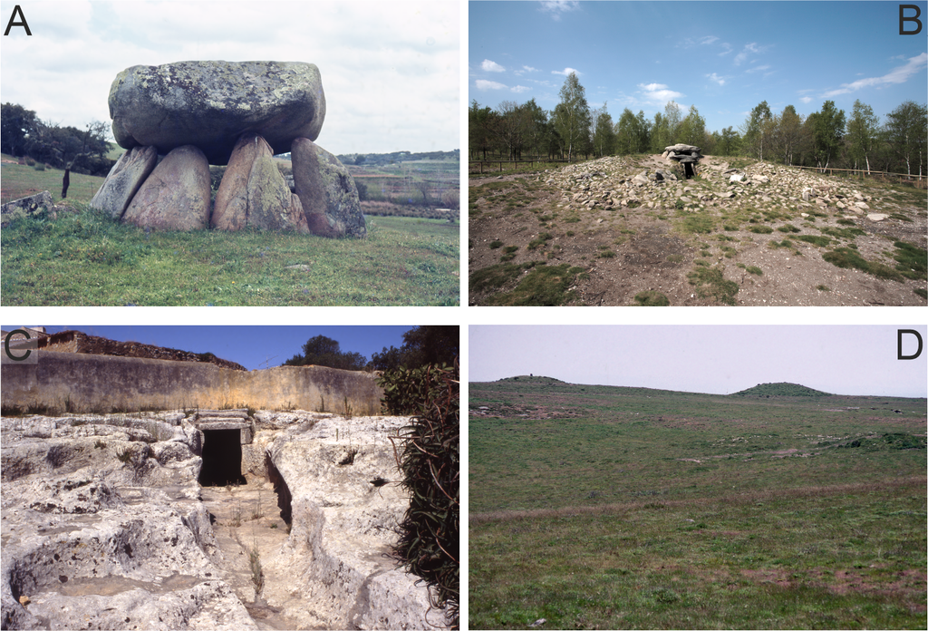

Figure 1: Different megalithic architectures in the Iberian Peninsula. A: A Ordem (Alentejo); B: A Mámoa do Rei (Galicia); C: Rock-cut-tomb of Alapraia (Estoril); D: Mounds of Serra do Leboreiro (Northwest border of Portugal). Photographs A and C by Antón A. Rodríguez Casal, published under a CC BY 4.0 license with permission. Photographs B and D by the authors.

The chronology of European megalithic sites has been heavily debated among archaeologists over the last century, especially since the introduction of radiocarbon dating in the 1960s (Case, 1969; Renfrew, 1976). The early models proposed in the 1930s suggested a diffusion of megaliths from the Near-East (Renfrew, 1976), but these explanatory hypotheses have subsequently been replaced by models that pointed out the existence of several European foci where megaliths would have emerged independently, namely Brittany, Portugal, Scandinavia and Ireland, amongst others (Renfrew, 1973). Much of the recent research has dealt with how such megalithic architectures might have emerged, whether as a product of local innovation with strong Mesolithic roots (Bradley, 1998; Midgley, 2005; Vijande Vila, 2015), or as a result of external influences (Callaghan & Cooney, 2009; Carvalho, 2010; Cassidy et al., 2016; Schulz Paulsson, 2019; Sheridan, 2010; Zilhão, 2001). Turning to the Iberian context in particular, pioneering works by, for example, Bosch-Gimpera and Pericot during the 1930s (Bosch-Gimpera, 1925) proposed that it was two distinct regions, northern Portugal and north-western Spain (Galicia) that Iberian megaliths first appeared. This hypothesis relied on the documentation of archaeological materials from local Mesolithic traditions in several “proto-megalithic” chambers. Later, Bosch-Gimpera and Pericot’s interpretations were contested by several authors. Forde (1930) (1930), for example, rejected a local origin and focused instead on the East Mediterranean, identifying the corbel-vaulted tholos as possible inspiration for the Iberian monuments. G. Leisner (1938) and V. Leisner (1965) proposed an alternative view arguing the possible contemporaneity of several types of funerary architectures (e.g., simple dolmens and passage graves).

The radiocarbon and thermoluminescence dates published from the 1960s onwards gradually started to add to this picture, showing that some of the small cist burials and the passage tombs in western Iberia, such as Poço da Gateira or Anta de Gorginos (central Portugal), were —in fact— older than the corbel-vaulted tholoi. These relatively early dates led Colin Renfrew to propose the south-central Portugal as one of the areas of Europe where megalithic architecture developed independently (Renfrew, 1976). Renfrew’s model continues to be popular among Iberian researchers: on this view, megaliths would have originated in the Alentejo region at the turn of the 5th millennium BCE, subsequently spreading to other Iberian areas and peaking as a phenomenon during the 3rd millennium BCE (Lillios, 2019; Muñoz Ibáñez, 2021).

Recent treatments of the topic have added complexity to the origin and spread of the phenomenon in Iberia (García Sanjuán et al., 2022), particular with the suggestion that their examples of “proto-megalithic” or “pre-megalithic” architecture, characterised by earth mounds with small internal chambers can be found in different areas of Iberia around the 5th millennium BCE. At the same time, an increasing number of archaeological examples across Europe (Bueno Ramírez et al., 2016; Cassen et al., 2009; Gavilán Ceballos & Vera Rodríguez, 2005; Laporte & Tinevez, 2010) have indicated that such “proto-megalithic” and early megalithic structures may have reused menhirs and standing stones that began life as part of stone-lined enclosures. A lack of radiocarbon dates (Lillios, 2019) continues to hinder severely any accurate reconstruction of the building episodes in these earliest “proto-megalithic” chambers, but even so, growing archaeological evidence, such as morphometric data, suggests that some menhirs are in fact re-used in those structures (Bueno Ramírez et al., 2016; Cassen et al., 2009; De la Fuente Andrés, 1994; Laporte & Tinevez, 2010).

The grave goods found inside some Portuguese sites include microliths whose morphology can be traced back to local Mesolithic traditions (e.g. shell sites of Muge-Tajo, Lillios, 2019; Soares, 2000). Sites such as Campo de Hockey (Cádiz) or Arroyo Saladillo (Antequera, Andalusia), provide clear examples of very well dated early proto-megalithic structures (García Sanjuán et al., 2020; Vijande Vila, 2009, 2015). The former, Campo de Hockey burial 11, comprises a double inhumation and a single burial dated to the second half of the 5th millennium BCE. Likewise, Tomba de Segudet, in Andorra, represents another proto-megalithic structure dating to the same period (Morell Rovira et al., 2018). Those sites were used by García Sanjuán et al. (2022) to provide one of the first diffusion models of Iberian megalithism based on a selection of 27 radiocarbon dates, concluding the existence of two centres of megalithic origin and spread in the Iberian Peninsula: the south-western regions of Andalusia and the East of the Iberian Peninsula.

In some areas, the origin of the megalithic phenomenon can be also read as a result of cultural interaction among different areas along the Atlantic coast, with Brittany playing a major role (Cassen, 2012; Cassen & Grimaud, 2019; Schulz Paulsson, 2017, 2019). Several authors (Bueno Ramírez et al., 2012; López-Romero, 2017; Rodríguez-Rellán et al., 2020) have highlighted the existence of an important number of similar traits in the megalithic phenomenon of France, Ireland, Portugal and Atlantic Spain. These include common types of architecture, analogous graphical representations engraved inside the monuments (Cassen, 2015) and some shared material culture from within the structures. Among the latter portable objects, there is ample evidence for the circulation of polished axes made on Alpine jade (Fábregas Valcarce & Rodríguez-Rellán, 2012; Pétrequin et al., 2012) or the presence of body ornaments made of Iberian variscite among the grave goods of some of the major Breton mounds (Bosch et al., 2020; Rodríguez-Rellán et al., 2020). This growing body of evidence strongly suggests a significant degree of connectivity along the shores of Atlantic Europe of Western Europe since at least the Neolithic. These connections, in which maritime interactions probably played a very important role, would have allowed the exchange of objects but perhaps also the emergence of a set of shared beliefs and practices around the megalithic architectures (Cunliffe, 2001, p. 211), a pattern further supported by recent ancient DNA studies indicating population connections along the Atlantic façade (e.g. Sánchez-Quinto et al., 2019).

Radiocarbon datasets are very important for understanding the megalithic phenomenon in Iberia, but they are not homogeneous in terms of dated material. In particular, the regions draining into the Atlantic Ocean facing a significant handicap with respect to certain organic samples. Acidic soils hinder the preservation of bones in burial contexts, a fact very visible for example in northwest Iberia, resulting in the absence of human skeletal remains and forcing radiocarbon dating to rely on charred wood (2). The result is a large-scale spatial dichotomy between the northern half of the Iberian Peninsula where the available radiocarbon dates are predominantly obtained from charcoal and the southern half, where dates are largely based on human bone samples. This paper revisits this dichotomy and suggests the presence of bias that has significant consequences for the conclusions which may currently be drawn.

**Code for Figure 2**

```r
# Figure 2. Distribution of all C14 dates and material type bias ----
# Libraries and set-up ----
library(sf)
if (!requireNamespace("rnaturalearthhires", quietly = TRUE))
  remotes::install_github("ropensci/rnaturalearthhires")
library(rnaturalearth)
library(spatstat)
library(here)

# Load basemaps ----
iberia <- ne_countries(
  country = c("spain", "portugal"),
  returnclass = "sf",
  scale = 10
)
iberia <- st_cast(st_geometry(iberia), "POLYGON")
iberia <- iberia[st_coordinates(st_centroid(iberia))[, "X"] > -10]
iberia <- st_union(
  iberia[st_area(iberia) > units::set_units(50000000, "m^2")]
)
iberia <- st_transform(iberia, 25829)
franceandorra <- st_cast(
  st_geometry(ne_countries(
    country = "france", returnclass = "sf", scale = 10
  )), "POLYGON"
)
franceandorra <- franceandorra[
  st_area(franceandorra) == units::set_units(
    max(st_area(franceandorra)), "m^2"
  )
]
franceandorra <- st_union(
  franceandorra,
  st_geometry(ne_countries(
    country = "andorra", returnclass = "sf", scale = 10
  ))
)
franceandorra <- st_transform(franceandorra, 25829)
northafrica <- ne_countries(
  country = c("morocco", "algeria"),
  returnclass = "sf", scale = 10
)
northafrica <- st_cast(st_geometry(northafrica), "POLYGON")
northafrica <- st_union(
  northafrica[st_area(northafrica) > units::set_units(50000000, "m^2")]
)
northafrica <- st_transform(northafrica, 25829)
andorra <- st_cast(
  st_geometry(ne_countries(
    country = "andorra", returnclass = "sf", scale = 10
  )), "POLYGON"
)
andorra <- st_transform(andorra, 25829)
iberia_andorra <- st_union(iberia, andorra)

# Load radiocarbon dates and convert to spatial data ----
dates <- read.csv(
  here("data", "C14dates_Iberia_raw.csv"),
  sep = ";", dec = ","
)
dates[dates$LabNumber == "UBAR-630", "Northings_Y"] <-
  dates[dates$LabNumber == "UBAR-630", "Northings_Y"] - 1000
dates <- st_as_sf(dates, coords = c(4, 5))
st_crs(dates) <- 25829 # LAEA ETRS89
set.seed(123)
dates <- st_jitter(dates, 2) # jitter all dates by 2m
charcoaldates <- dates[dates$Material == "Charcoal", ]
otherdates <- dates[dates$Material != "Charcoal", ]

# Spatial density of all dates ----
mysd <- scalesize <- 40000
cellres <- 1000
dates_ppp <- ppp(
  st_coordinates(dates)[, 1],
  st_coordinates(dates)[, 2],
  as.owin(iberia_andorra)
)
dates_dens <- density(dates_ppp, eps = cellres, sigma = mysd, edge = FALSE)
charcoaldates_ppp <- ppp(
  st_coordinates(charcoaldates)[, 1],
  st_coordinates(charcoaldates)[, 2],
  as.owin(iberia)
)
charcoaldates_dens <- density(
  charcoaldates_ppp,
  eps = cellres,
  sigma = mysd,
  edge = FALSE
)

# Relative risk of charcoal as percentage, with denominator cutoff ----
cutoff <- 1e-10
dates_dens_na <- dates_dens
dates_dens_na[as.matrix(dates_dens) < cutoff] <- NA
charcoaldates_perc <- charcoaldates_dens / dates_dens_na * 100
dates_dens_per100sqkm <- dates_dens_na *
  (dates_dens$xstep * dates_dens$ystep) * 100

# Plot ----
cm2 <- colourmap(
  col = rev(heat.colors(10)),
  range = c(min(charcoaldates_perc), max(charcoaldates_perc))
)
png(filename = here("figures", "Figure 2.png"), width = 700, height = 800)
par(mfrow = c(2, 1))
par(mar = c(0.1, 0.1, 0.1, 0.1))
# panel 1
plot(iberia_andorra, border = NA, col = "grey75")
plot(franceandorra, col = "grey90", border = NA, add = TRUE)
plot(northafrica, col = "grey90", border = NA, add = TRUE)
plotlim <- par("usr") # x1 x2 y1 y2
xlimramp <- c(1600000, 1650000)
ylimramp <- c((plotlim[3] + 650000), (plotlim[3] + 850000))
plot(dates_dens_per100sqkm, add = TRUE)
plot(iberia_andorra, border = "grey75", col = NA, lwd = 0.5, add = TRUE)
plot(
  st_geometry(dates),
  add = TRUE,
  col = "black",
  pch = 1,
  cex = 0.3,
  lwd = 0.5
)
xmax <- max(dates_dens_per100sqkm)
xticks <- seq(0, xmax, xmax / 4)
to <- c(ylimramp[1], ylimramp[2])
xrange <- range(seq(0, xmax, xmax / 4))
mfac <- (to[2] - to[1]) / (xrange[2] - xrange[1])
xticksrs <- to[1] + (xticks - xrange[1]) * mfac
xticks_text <- signif(xticks, digits = 3)
xticks_text[1] <- "0"
plot(
  colourmap(Kovesi$values[[29]], range = c(0, xmax)),
  vertical = TRUE,
  main = "",
  ylim = ylimramp,
  xlim = xlimramp,
  axes = FALSE,
  add = TRUE
)
# Add custom axis with proper labels ----
axis(4, at = xticksrs, labels = xticks_text, cex.axis = 1, las = 2)
text(
  1625000, 4840000, "dates/100 sqkm",
  cex = 1, font = 2, col = "black"
)
xpos <- 1600000
ypos <- 4100000
scalesize <- mysd * 6
x <- seq(0 - (scalesize / 2), 0 + (scalesize / 2), 100)
xx <- x + xpos
y <- dnorm(x, mean = 0, sd = mysd)
yy <- (y / max(y) * (scalesize * 0.6)) + ypos
xsd <- seq(0 - mysd, 0 + mysd, 100)
xxsd <- xsd + xpos
ysd <- dnorm(xsd, mean = 0, sd = mysd)
yysd <- (ysd / max(ysd) * (scalesize * 0.6)) + ypos
xxsd <- xxsd[median(seq_along(xxsd)):length(xxsd)]
yysd <- yysd[median(seq_along(yysd)):length(yysd)]
polygon(
  c(xx, max(xx), min(xx), min(xx)),
  c(yy, ypos, ypos, yy[1]),
  col = "grey75",
  border = NA
)
polygon(
  c(xxsd, max(xxsd), min(xxsd), min(xxsd)),
  c(yysd, ypos, ypos, yysd[1]),
  col = "grey50",
  border = NA
)
text(
  xpos, ypos - 20000,
  expression(paste(sigma, "=40 km", sep = "")),
  cex = 0.7, col = "black"
)
lines(c(xpos, xpos), c(ypos, max(yy)), col = "grey50")
text(
  xpos, ypos + 170000, "N",
  cex = 1.2, font = 2, col = "black"
)
text(
  x = 1175000, y = 4450000, "insufficient\ndata",
  srt = 65, cex = 1, font = 3
)
text(350000, 4000000, "A", cex = 1.5, font = 2, col = "black")
box()
# panel 2 ----
plot(iberia_andorra, border = NA, col = "grey75")
plot(franceandorra, col = "grey90", border = NA, add = TRUE)
plot(northafrica, col = "grey90", border = NA, add = TRUE)
plot(charcoaldates_perc, col = cm2, add = TRUE)
plot(iberia_andorra, border = "grey75", col = NA, lwd = 0.5, add = TRUE)
plot(
  st_geometry(dates[
    dates$Material %in% c("Human bone", "Human teeth"),
  ]),
  add = TRUE,
  col = "cyan",
  pch = 19,
  cex = 1
)
plot(
  st_geometry(charcoaldates),
  add = TRUE,
  col = "black",
  pch = 19,
  cex = 1
)
plot(
  st_geometry(dates[!dates$Material %in% c(
    "Charcoal",
    "Human bone",
    "Human teeth"
  ), ]),
  add = TRUE,
  col = "purple",
  pch = 4,
  cex = 0.5
)
legend(
  xpos - 140000,
  ypos + 220000,
  legend = c("charcoal", "human bone/teeth", "other"),
  bty = "n",
  col = c("black", "cyan", "purple"),
  pch = c(19, 19, 4),
  pt.cex = c(0.6, 0.6, 0.7),
  cex = 1
)
text(100000, 75000, "A", cex = 1.2, font = 2, col = "black")
plot(
  cm2,
  vertical = TRUE,
  main = "",
  ylim = ylimramp,
  xlim = xlimramp,
  cex.axis = 1,
  las = 2,
  labelmap = function(x) round(x, digits = 0),
  add = TRUE
)
text(
  1625000, 4825000, "% charcoal",
  cex = 1, font = 2, col = "black"
)
text(350000, 4000000, "B", cex = 1.5, font = 2, col = "black")
text(
  x = 1175000, y = 4450000, "insufficient\ndata",
  srt = 65, cex = 1, font = 3
)
box()
dev.off()

# Session information for reproducibility ----
si <- sessionInfo()
# print(si)
```

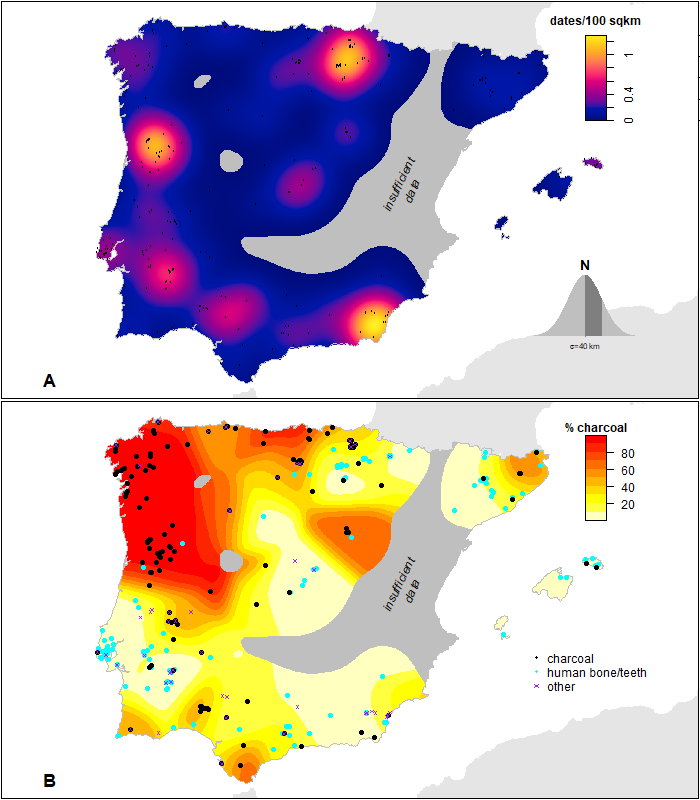

Figure 2: Spatial distribution of radiocarbon dating intensity and charcoal-dating bias across Iberian megalithic contexts. A) The density of radiocarbon dates per 100 km² as potentially relevant to the Iberian megalithic phenomenon. B) The percentage of dates which are charcoal relative to total megalith-related dates in that area. Base maps created with Natural Earth public domain map data (http://www.naturalearthdata.com/).

2 B clearly illustrates this spatial dichotomy: the chronology of northwestern megaliths and adjacent regions is mainly built over charcoal samples, whereas those from the south and east rely mostly on short-lived samples. This situation justifies the need to test models that specifically attempt to correct for this bias, or which exclude the use of charcoal in these regions altogether (García Sanjuán et al., 2022; Linares Catela, 2022; Santa Cruz, 2024).

In numerical terms, of the 135 dates included in our database for north Iberian regions, 100 were obtained from charcoal (usually Quercus where known, but in most cases the species was not identified nor the part or the tree ring curvature). This pattern may be artificially causing older chronological trends in areas such as Galicia, Asturias, or northern Portugal due to an anticipated old wood effect (perhaps of 200 years in the case of oak, but potentially more for certain other species). This is the reason why previous work applied strict radiocarbon date hygiene protocols and only considered one date for Galicia and Asturias (García Sanjuán et al., 2022).

In this paper, however, we move beyond traditional chronological compilations by critically evaluating the reliability of the whole, available radiocarbon record, with a particular focus on biases introduced by sample material (e.g. an “old wood effect”). We employ a robust statistical framework combining a Bayesian Phase model to estimate the origination date of megalithic construction in Iberia along with spatially explicit, quantile regression models to discuss the origin and spread of the phenomenon. This combination allows us to formally test previous hypotheses regarding the origin of the phenomenon, and offer a new, statistically grounded perspective on one of the most relevant topics in the European later prehistory.

# 2 Material and Methods

We have collected a total of 1,219 dates from 392 megalithic monuments, starting with Schulz Paulsson’s important, open access dataset (Schulz Paulsson, 2017, 2019) and checking these individually against other major compendia, namely IDEArqC14 (Uriarte González, 2017), CronoloGEA (Aranda Jiménez & Lozano Medina, 2015) and “Cronología de la Prehistoria de la Península Ibérica” (SIAC, Alday Ruiz & Mejías-García, 2019). We also carried out a revision of the grey regional literature to collect the latest radiocarbon dates and tried to define the architectural class for each of the sites.

From the initial number of 1,219 dates, 172 were formally discarded following five criteria detailed in the supplementary material (see ESM 1 Database description and Table S4): 1) Non-megalithic architectures (n=41) such as open-air settlements, caves or non-funerary megalithic sites like menhirs and stone circles; 2) Chronological boundaries (n=53), falling outside the 5500-2500 BCE analytical window; 3) Contextually anomalous or unreliable dates (n=38), identified in regional literature as aberrant due to contaminations or inconsistent with regional chrono-cultural sequences; 4) Lack of essential contextual or provenance data (n=26); 5) Extremely high uncertainty (n=14), where standard errors exceeded $\sigma > 150$ years. The resulting curated database comprises 1,047 valid dates from 337 megalithic monuments spanning from 5500 to 2500 BCE.

While several thousand megalithic monuments are recorded through the Iberian Peninsula (Scarre, 2020), a vast majority remain unexcavated and undated. The 392 sites compiled here represent the full extent of the currently available radiocarbon-dated megalithic record. Although differential research intensity inevitably affects spatial sample density, the dataset compiled for this paper all encompasses all major physiographic zones, river basins and architectural traditions across Iberia.

Radiocarbon dates were calibrated using OxCal (Bronk Ramsey, 1995), the *rcarbon* (Crema & Bevan, 2021) and *oxcAAR* packages in R 4.5.1, applying the IntCal20 curve (Reimer et al., 2020). To model the temporal dynamics of the phenomenon we implemented a Bayesian trapezoidal model (Crema & Kobayashi, 2020; Lee & Ramsey, 2012) to formalise regional intensities as a generative process defined by four transition boundaries: onset, peak start, peak end, and disappearance. Posterior distributions for these parameters were estimated via MCMC sampling (N=100,000).

## 2.1 Chronological and spatial modelling

Recent research by Bettina Schulz Paulsson (2019) has defined a phase of megalithic expansion in Europe spanning the late 5th to the early 3rd millennium BCE, starting in northwest France and spreading throughout Europe, the Atlantic and Mediterranean coasts to several regions, such as Iberia. To model specific putative origin(s) in the Iberian Peninsula, we have followed the approach developed by Silva et al. (2015) in using quantile regressions of the radiocarbon dates and geodesic distances from several putative origin models.

Specifically, we modelled the relationship between each site date (median calibrated date as the dependent variable) and its distance from a selected putative origin (covariate) using quantile regression, with goodness of fit assessed from regressions of radiocarbon dates against Euclidean distances between points. For each origin point, we fitted a quantile regression

$$\text{CalBP} = \beta_0 + \beta_1 \times \text{Distance},$$

where CalBP is the median calibrated radiocarbon age of each site, Distance is its Euclidean distance from the origin point, $\beta_0$ is the intercept and $\beta_1$ the regression slope. Under a diffusion model, where site chronology is expressed in calibrated radiocarbon years BP, the expected relationship is negative ($\beta_1 < 0$), indicating that sites become progressively younger (lower calBP values) with increasing distance from the source. Conversely, positive slopes ($\beta_1 > 0$) indicate that sites become older with increasing distance from the source, thereby identifying origin points that are inconsistent with an expansive process.

All distances were computed Euclidean distances in the projected coordinate system (UTM Zone 29N, EPSG:32629), rather than topographically alternative approaches such as least-cost paths. While topographic friction may influence the local movement in rugged terrain, we argue that at the peninsular scale of this analysis (~1,000 km) and given the broad chronological windows involved (centuries to millennia), Euclidean distances provide a reasonable first approximation. This approach is consistent with previous implementations of the method (Silva et al., 2015).

The identification of the origin for the spread was carried out by identifying origin points that would maximise out of sample predictive accuracy using AIC, a statistical criterion widely used for model selection and validation (Baddeley et al., 2016; Burnham & Anderson, 2002; Towner & Luttbeg, 2007). The interpolated surface should not be interpreted as representing additional evaluated origins, but rather as a continuous representation of the underlying grid search (3).

**Code for Figure 3**

```r
# Figure 3. Modeling the geographical origin and spread -----
# Quantile regression of all dates (using median calBP)

## Libraries and set-up
library(spatstat)
library(oxcAAR)
library(rcarbon)
library(dplyr)
library(sp)
library(sf)
library(rnaturalearth)
library(raster)
library(quantreg)
library(gstat)
library(ggplot2)
library(tidyverse)
library(here)

# Also need rnaturalearthhires
remotes::install_github("ropensci/rnaturalearthhires")

install.packages(
  "rnaturalearthhires",
  repos = "https://ropensci.r-universe.dev",
  type = "source")

## Read raw data -----
dates <- read.csv(here("data", "C14dates_Iberia_raw.csv"),
                  sep = ";",
                  na = "n/a")
## Select only non-excluded dates
dates <- subset(dates, Excluded == "No")
## Create specific site ID
dates$SiteID <- paste0("S", as.numeric(as.factor(dates$Site)))

# Calibrate dates -----
dates_cal <- calibrate(
  x = dates$C14,
  errors = dates$STD,
  normalised = TRUE,
  calMatrix = TRUE,
  calCurves = "intcal20"
)
cal_sum_dates <- summary(dates_cal)
medianBP <- cbind(cal_sum_dates$DateID, cal_sum_dates$MedianBP)
medianBP <- as.numeric(medianBP[, 2])

## Read Site Coordinates and Compute Distance from Grid
sites.coords <- dplyr::select(dates,
                              SiteID,
                              Eastings_X,
                              Northings_Y) # In ETRS_1989_UTM_Zone_29N
coordinates(sites.coords) <- c("Eastings_X", "Northings_Y")
proj4string(sites.coords) <- CRS("+proj=utm +zone=29 +ellps=GRS80 +towgs84=0,0,0,0,0,0,0 +units=m +no_defs")

## Create window of analyses
spdf_spain <- ne_countries(country = "spain",
                           scale = 10,
                           returnclass = "sf")
spdf_portugal <- ne_countries(country = "portugal",
                              scale = 10,
                              returnclass = "sf")
window <- st_union(spdf_spain, spdf_portugal)
window <- st_transform(window, crs = "+proj=utm +zone=29 +ellps=GRS80 +towgs84=0,0,0,0,0,0,0 +units=m +no_defs")
bbox <- cbind(c(388528.4, 3935709), c(1570529.0, 4903406))
b_poly <- st_as_sfc(st_bbox(c(xmin = bbox[1, 1],
                              ymin = bbox[1, 2],
                              xmax = bbox[2, 1],
                              ymax = bbox[2, 2]),
                            crs = st_crs(window)))
window <- st_intersection(window, b_poly)
## Convert to Spatial object for compatibility with sp-based functions
window <- as(window, "Spatial")

## Create grid points
gridPts <- spsample(window, n = 5000, type = "regular")

## Compute distances between grid points and sites
distMat <- spDists(sites.coords,
                   gridPts,
                   longlat = FALSE)

## Quantile Regression Loop ----
AICs <- numeric(length(gridPts))
tau <- 0.9
coeff <- numeric(length(gridPts))
for (i in seq_along(gridPts)) {
  CalBP <- medianBP
  geoDist <- distMat[, i]
  tmp_model <- rq(CalBP ~ geoDist, tau = tau)
  AICs[i] <- AIC(tmp_model)
  coeff[i] <- coefficients(tmp_model)[2]
}
gridPts <- as(gridPts, "SpatialPointsDataFrame")
gridPts@data <- data.frame(AICs = AICs,
                           DeltaAIC = AICs - min(AICs),
                           Coeff = coeff)

# Interpolation via IDW ----
## Create grid for interpolation (50,000 points)
grd <- as.data.frame(spsample(gridPts, "regular", n = 50000))
names(grd) <- c("X", "Y")
coordinates(grd) <- c("X", "Y")
gridded(grd) <- TRUE # Create SpatialPixel object
fullgrid(grd) <- TRUE # Create SpatialGrid object

## Add P's projection information to the empty grid
proj4string(gridPts) <- proj4string(gridPts)
proj4string(grd) <- proj4string(gridPts)
idw.dAIC <- gstat::idw(DeltaAIC ~ 1,
                       gridPts,
                       newdata = grd,
                       nmin = 8,
                       nmax = 12)
idw.dAIC.r <- raster(idw.dAIC)
idw.dAIC.m <- mask(idw.dAIC.r, window)
idw.coeff <- gstat::idw(Coeff ~ 1,
                        gridPts,
                        newdata = grd,
                        nmin = 8,
                        nmax = 12)
idw.coeff <- raster(idw.coeff)
idw.coeff.m <- mask(idw.coeff,
                    window)

# Make the plot -----
pal <- c("blue", "yellow", "orange", "red") # Set palette
IdWSurface.dAIC <- rasterToPoints(idw.dAIC.m, xy = TRUE) %>%
  as_tibble() %>%
  gather(var, value, -x, -y)
IdWSurface.coeff <- rasterToPoints(idw.coeff.m, xy = TRUE) %>%
  as_tibble() %>%
  gather(var, value, -x, -y)

## Plot figure
plot0 <- ggplot() +
  geom_tile(data = IdWSurface.dAIC,
            mapping = aes(x = x, y = y, fill = value)) +
  scale_fill_gradientn(colours = pal, na.value = "white",
                       limits = c(0, 175),
                       breaks = c(0, 5, 10, 15, 50, 175)) +
  geom_sf(data = st_as_sf(window), fill = NA) +
  theme_bw() +
  geom_contour(data = IdWSurface.coeff, mapping = aes(x = x, y = y, z = value),
               breaks = 0, col = "black", linetype = 2) +
  labs(x = "", y = "", title = "IDW AICs Interpolation (all 14C dates, median calBP)",
       fill = bquote("AICs")) +
  coord_sf(xlim = extent(window)[1:2],
           ylim = extent(window)[3:4],
           datum = sf::st_crs(window)) +
  theme(
    panel.background = element_rect(fill = "white", color = "gray50"),
    axis.text.y = element_text(angle = 90, hjust = 0.7),
    axis.text.x = element_text(angle = 0, hjust = 0.7),
    legend.text = element_text(size = 10),
    legend.position = "right",
    legend.key.width = unit(1, "line"),
    legend.key.height = unit(4, "line")
  ) +
  guides(shape = guide_legend(override.aes = list(size = 10))) +
  annotate("text", x = 780000, y = 4570000, label = "Positive Beta") +
  geom_point(data = dates, aes(x = Eastings_X, y = Northings_Y),
             colour = "black",
             shape = 19,
             size = 0.5) +
  annotate("text",
           x = 1000000,
           y = 4300000,
           label = "Negative Beta") +
  annotate("text",
           x = 700000,
           y = 4760000,
           label = "Lowest AIC")

## Save the figure
ggsave(filename = here("figures", "Figure 3.png"),
  plot = plot0,
  width = 13,
  height = 8,
  dpi = 300,
  units = "in")

# Session information for reproducibility
si <- sessionInfo()
# print(si)
```

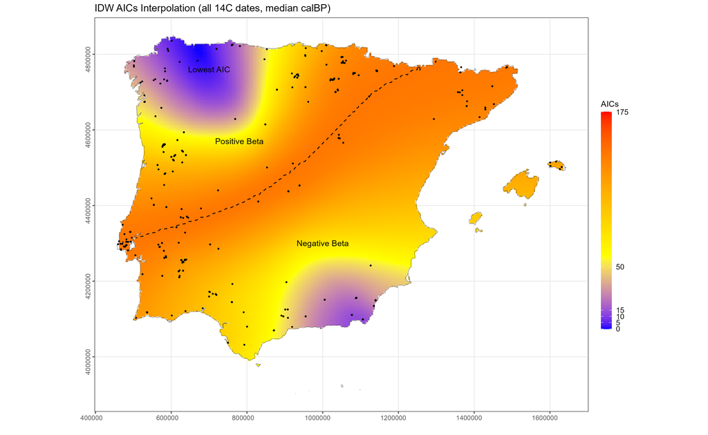

Figure 3: Inverse distance weighted (IDW) interpolation of ΔAIC values derived from a grid-based quantile regression analysis. Lower ΔAIC values indicate a better statistical fit of an origin point to the observed age–distance relationship. The dashed contour marks the boundary where the regression slope (β₁) equals zero, separating origins producing positive (β₁ > 0) and negative (β₁ < 0) age–distance relationships. The global minimum ΔAIC among the evaluated grid points is located in northwestern Iberia. Although the interpolated surface also shows a secondary area of relatively low ΔAIC values in the southeast, this feature results from the IDW interpolation used for visualization and does not represent an equivalent optimum in the underlying grid search. Base maps created with Natural Earth public domain map data (http://www.naturalearthdata.com/).

1. North-western origin (NW): territories comprising the Northwestern area of Spain (mainly Galicia and Asturias) and the North of Portugal. The specific points to report depend on the analytical results (unconstrained search).
2. South-western origin (SW): located in the Algarve region. Longitude: -8.182; Latitude: 37.250.
3. North-eastern origin (NE): located in the Tavertet region (Catalonia). Longitude: 2.516; Latitude: 42.031.
4. Double origin: comprising the NW and SW points.
5. Campo de Hockey origin: located in San Fernando, Cádiz.
6. Double origin: comprising Campo de Hockey and Northeast points.
7. Triple origin: comprising NW, SW and NE points of origin.

We calculated the $\Delta\text{AIC}$ value for these models to identify the most probable origin point. This comparison was conducted across three analytical scenarios: (1) the raw radiocarbon dataset, (2) a dataset corrected by −500 years for charcoal samples from high-charcoal regions, and (3) a bone/teeth-only subset. The full results of this model comparison, including AIC values, regression slopes, and estimated diffusion velocities, are provided in Table S1.

## 2.2 Spatial analyses of sample types

Previous approaches to the origin and spread of the megalithic complex in Iberia addressed the topic using descriptive plots and interpolation of radiocarbon dates (García Sanjuán et al., 2022; Schulz Paulsson, 2017, 2019). While these studies acknowledge well-known issues associated with radiocarbon dating, particularly the old wood effect in charcoal samples, they do not incorporate this uncertainty into their spatial modelling, instead opting to exclude such dates.

To evaluate the potential impact of the old-wood effect on our diffusion models, we implemented two complementary analytical approaches:

1. a spatial analysis of the distribution of dated materials using kernel density estimation ($\sigma = 40$ km), identifying regions of Iberia where charcoal samples represented >70% of the dated assemblage. This threshold corresponds to approximately the 66th percentile of the charcoal percentage distribution across Iberia and was selected to identify areas with the highest concentration of charcoal dates while avoiding an overly restrictive definition.
2. A probabilistic sensitivity analysis evaluating the spatial robustness of the single-origin model under simulated old-wood corrections. Because OxCal cannot currently handle continuous 2D spatial regression likelihoods, evaluating this spatial sensitivity required an external routine. Rather than applying a deterministic subtraction to median calibrated dates, we implemented a Monte Carlo calibrated distribution sampling approach. For each of 500 simulations, calendar dates were sampled directly from the full IntCal20 calibrated probability density of each sample, using `sampleDates()` function in *rcarbon* package.

For charcoal samples from these high-charcoal regions, dates were progressively reduced by 0-1,200 years in 100-year increments, simulating increasing magnitudes of the old-wood effect. For each correction scenario, the complete quantile-regression analysis was rerun across all 1,000 origin points. The location yielding the lowest AIC was recorded for each iteration, allowing us to evaluate whether progressively larger corrections resulted in a spatial shift of the inferred diffusion origin. For our general diffusion model, we determined a critical threshold which helped us to value the precise magnitude of error required to shift between hypothetical origin centers. This was defined as the minimum correction value at which the optimum origin center exceeded 700 km (UTM Zone 29N), generally representing the geographic transition from Northwest to Eastern/Interior Iberia. Uncertainty was summarized via 50% and 95% credible envelopes around the median trend.

The statistical thresholds were contextualized with specific data from palynological analyses and archaeological contexts. In the context of NW Iberia, the dominance of *Quercus* sp. (Oak) can be seen, a long-lived genus (from 100 to 1,000 years) alongside shorter-lived taxa such as *Corylus* (hazel) (<100 years) (see ESM 2). By mapping these lifespans onto the sensitivity curve, we were able to define two analytical zones: short-lived species (0-100 years offset), and long-lived lifespan (100–1,000 years offset).

## 2.3 Regional spatio-temporal trajectories

The onset of the emergence, peaking, and disappearance of the megalithic phenomenon across different regions were inferred using a Bayesian trapezoidal model. By treating the radiocarbon record as a proxy for megalithic intensity, we defined four parameters (onset, peak, decline, and disappearance), which were estimated in six pre-defined regions in the Iberian Peninsula. Raw posterior estimates (median, 95% HDPI) and Bayesian model agreement indices (Amodel) for each region and parameter are provided in Tables S2 (full dataset) and S3 (bone/teeth only). The choice of six regions is grounded in the natural geography of the Iberian Peninsula: the Atlantic North, the Mediterranean East, and the four main river basins (Duero, Tagus, Ebro, and Guadalquivir/South). These divisions align with recognized environmental and cultural spheres in Iberian prehistory (e.g. García Sanjuán et al., 2022). This approach allows for a formal characterization of patterns in the adoption and consolidation of megalithic practices while explicitly modelling chronological uncertainty associated with the radiocarbon record and cultural phase transitions. The resulting posterior distributions provide probabilistic estimates of the intensity of the phenomenon, distinguishing between initial pioneer events and the long-term establishment of monumental funerary landscapes. As a sensitive approach, we have also compared Bayesian trapezoidal models from bone and teeth samples, representing direct dates of monument use, against the full radiocarbon dataset (bone and charcoal combined). This comparative analysis was restricted to the four regions with sufficient bone dates (East, Tagus Basin, South, and Ebro Basin), allowing us to evaluate the extent to which charcoal-derived dates effect introduce temporal shifts in each regional sequence.

# 3 Results

**Code for Figure 4**

```r
# Figure 4 - Sensitivity Curve Analysis ----
# Load libraries
library(sf)
library(sp)
library(raster)
library(rcarbon)
library(quantreg)
library(rnaturalearth)
library(rnaturalearthdata)
library(spatstat)
library(dplyr)
library(ggplot2)
library(here)
library(parallel)

# Part 1. Data Preparation ----
# Read data
dates <- read.csv2(
  file = here("data", "C14dates_Iberia_raw.csv"),
  header = TRUE,
  sep = ";")

dates <- dates[dates$Excluded == "No", ]

# Calibrate dates ----
dates_cal <- calibrate(
  x = dates$C14,
  errors = dates$STD,
  normalised = TRUE,
  calCurves = "intcal20")

dates$medianBP <- summary(dates_cal)$MedianBP

# Create spatial window ----
spdf_spain <- ne_countries(country = "spain", scale = 10, returnclass = "sf")
spdf_portugal <- ne_countries(country = "portugal", scale = 10, returnclass = "sf")
iberia <- st_union(spdf_spain, spdf_portugal)
iberia <- st_cast(st_geometry(iberia), "POLYGON")
iberia <- iberia[st_coordinates(st_centroid(iberia))[, "X"] > -10]
iberia <- st_union(iberia[st_area(iberia) > units::set_units(50000000, "m^2")])
iberia <- st_transform(iberia, 25829)
andorra <- st_cast(
  st_geometry(ne_countries(country = "andorra", scale = 10, returnclass = "sf")),
  "POLYGON")

andorra <- st_transform(andorra, 25829)
iberia_andorra <- st_union(iberia, andorra)

# Convert to spatial points ----
dates <- st_as_sf(dates, coords = c(4, 5))
st_crs(dates) <- 25829
set.seed(123)
dates <- st_jitter(dates, 2)

# Separate charcoal dates ----
charcoaldates <- dates[grepl("charcoal|Charcoal", dates$Material,
                             ignore.case = TRUE), ]

# Calculate spatial density for charcoal areas ----
mysd <- 40000
cellres <- 1000
dates_ppp <- ppp(
  st_coordinates(dates)[, 1],
  st_coordinates(dates)[, 2],
  as.owin(iberia_andorra))

dates_dens <- density(dates_ppp, eps = cellres, sigma = mysd, edge = FALSE)
charcoaldates_ppp <- ppp(
  st_coordinates(charcoaldates)[, 1],
  st_coordinates(charcoaldates)[, 2],
  as.owin(iberia))

charcoaldates_dens <- density(charcoaldates_ppp,
                              eps = cellres,
                              sigma = mysd, edge = FALSE)

cutoff <- 1e-10
dates_dens_na <- dates_dens
dates_dens_na[as.matrix(dates_dens) < cutoff] <- NA
charcoaldates_perc <- charcoaldates_dens / dates_dens_na * 100

# Identify areas of high charcoal (>=70%) ----
charcoal_perc_raster <- raster(charcoaldates_perc)
high_charcoal_mask <- charcoal_perc_raster >= 70
high_charcoal_mask[is.na(high_charcoal_mask)] <- FALSE
high_charcoal_coords <- rasterToPoints(high_charcoal_mask,
                                       fun = function(x) x == 1)

# Transform to UTM 29N ----
window_utm <- st_transform(iberia_andorra, 32629)
high_charcoal_sf <- st_as_sf(as.data.frame(high_charcoal_coords[, 1:2]),
                             coords = c("x", "y"),
                             crs = 25829)

high_charcoal_sf <- st_transform(high_charcoal_sf, 32629)
high_charcoal_buffer <- st_buffer(st_union(high_charcoal_sf), dist = 1000)

# Match Figure 3 data and define NW ----
# Use the same bounding box as Figure 3 for consistency
bbox <- st_bbox(c(xmin = 388528.4, ymin = 3935709, xmax = 1570529.0, ymax = 4903406),
                crs = 32629)
window_utm <- st_as_sfc(bbox)

# Filter dates within window of analysis
dates_utm <- st_transform(dates, 32629)
dates_in_window <- st_intersects(dates_utm, window_utm, sparse = FALSE)[, 1]
dates_utm <- dates_utm[dates_in_window, ]

# Identify NW dates for correction ----
# NW is defined as the Easting < 750,000 (covering Portugal and Galicia)
is_charcoal_utm <- grepl("charcoal|Charcoal", dates_utm$Material, ignore.case = TRUE)
is_in_nw <- st_coordinates(dates_utm)[, 1] < 750000
is_target_date <- is_charcoal_utm & is_in_nw

# Create grid for the analysis ----
gridPts <- st_sample(window_utm, size = 1000, type = "regular")
gridPts <- st_sf(geometry = gridPts)
distMat_all <- st_distance(dates_utm, gridPts)

# Part 2. Monte Carlo Sensitivity analysis with Calibrated Distribution Sampling ----
n_sim           <- 500       # Number of Monte Carlo draws per correction level
n_cores         <- 20        # This was run on a Workstation Threadripper PRO 7965WX
force_recompute <- FALSE     # If this is set to TRUE, it will recalculate. If FALSE, it loads saved .rds present in /simresults folder

# Save results
cache_dir  <- here("simresults")
dir.create(cache_dir, showWarnings = FALSE)
cache_file <- file.path(cache_dir, sprintf("figure4_mc_sim_N%d.rds", n_sim))

if (!force_recompute && file.exists(cache_file)) {
  all_sim_df <- readRDS(cache_file)
} else {
  dates_cal_utm <- calibrate(
    x = dates_utm$C14,
    errors = dates_utm$STD,
    normalised = TRUE,
    calCurves = "intcal20")

  set.seed(456)
  # Matrix of dimension: n_sim x nrow(dates_utm)
  cal_samples <- sampleDates(dates_cal_utm, nsim = n_sim, verbose = FALSE)$sdates

  corrections <- seq(0, 1200, by = 100)


  # Set up cluster for parallel calcuation
  cl <- makePSOCKcluster(min(n_cores, length(corrections)))

  # Worker function to evaluate all n_sim iterations for a single correction level
  eval_corr_worker <- function(corr, cal_samples, is_target_date, distMat_all, gridPts, n_sim) {
    iter_results <- data.frame(
      Correction = rep(corr, n_sim),
      Iteration  = seq_len(n_sim),
      CenterX    = numeric(n_sim),
      CenterY    = numeric(n_sim),
      MinAIC     = numeric(n_sim))

    for (b in seq_len(n_sim)) {
      sampled_bp <- cal_samples[b, ]
      # Subtract correction from NW charcoal dates in calendar dates (BP)
      sampled_bp[is_target_date] <- sampled_bp[is_target_date] - corr

      AICs <- numeric(nrow(gridPts))
      for (i in seq_len(nrow(gridPts))) {
        m <- tryCatch({
          mod <- quantreg::rq(sampled_bp ~ distMat_all[, i], tau = 0.9)
          if (coefficients(mod)[2] >= 0) NULL else mod
        }, error = function(e) NULL)
        AICs[i] <- if (!is.null(m)) AIC(m) else NA
      }

      min_idx <- which.min(AICs)
      best_pt <- sf::st_coordinates(gridPts)[min_idx, ]
      iter_results$CenterX[b] <- best_pt[1]
      iter_results$CenterY[b] <- best_pt[2]
      iter_results$MinAIC[b]  <- AICs[min_idx]
    }
    return(iter_results)
  }

  # Export required variables to cluster
  clusterExport(cl,
                c("cal_samples", "is_target_date", "distMat_all", "gridPts", "n_sim", "eval_corr_worker"),
                envir = environment())

  all_sim_list <- parLapply(cl, corrections, function(corr) {
    eval_corr_worker(corr, cal_samples, is_target_date, distMat_all, gridPts, n_sim)
  })
  stopCluster(cl)

  all_sim_df <- do.call(rbind, all_sim_list)
  saveRDS(all_sim_df, cache_file)
}

# Part 3. Statistical analysis and uncertainty envelope ----
THRESHOLD_EASTING <- 700000

# Summarize Monte Carlo envelope per correction step
envelope_df <- all_sim_df %>%
  group_by(Correction) %>%
  summarize(
    CenterX_med  = median(CenterX, na.rm = TRUE),
    CenterX_lo50 = quantile(CenterX, 0.25, na.rm = TRUE),
    CenterX_hi50 = quantile(CenterX, 0.75, na.rm = TRUE),
    CenterX_lo95 = quantile(CenterX, 0.025, na.rm = TRUE),
    CenterX_hi95 = quantile(CenterX, 0.975, na.rm = TRUE),
    Prob_NW      = mean(CenterX <= THRESHOLD_EASTING, na.rm = TRUE),
    .groups = "drop")

# Critical threshold: where median center X crosses the threshold
tipping_row <- envelope_df %>% filter(CenterX_med > THRESHOLD_EASTING) %>% slice(1)
tipping_val <- if (nrow(tipping_row) > 0) tipping_row$Correction else NA

# Range where 95% envelope crosses the threshold
crossing_rows_lo <- envelope_df %>% filter(CenterX_hi95 > THRESHOLD_EASTING) %>% slice(1)
crossing_rows_hi <- envelope_df %>% filter(CenterX_lo95 > THRESHOLD_EASTING) %>% slice(1)
tipping_lo <- if (nrow(crossing_rows_lo) > 0) crossing_rows_lo$Correction else NA
tipping_hi <- if (nrow(crossing_rows_hi) > 0) crossing_rows_hi$Correction else NA

# Part 4. Visualization (Figure 4) ----
p1 <- ggplot(envelope_df, aes(x = Correction)) +
  # Tree longevity areas
  annotate("rect",
           xmin = 0, xmax = 100, ymin = -Inf, ymax = Inf,
           fill = "green", alpha = 0.1) +
  annotate("rect",
           xmin = 100, xmax = 1200, ymin = -Inf, ymax = Inf,
           fill = "red", alpha = 0.1) +
  # Threshold line
  geom_hline(
    yintercept = THRESHOLD_EASTING,
    linetype = "dotted", color = "gray40", linewidth = 0.8) +
  annotate("text",
           x = 1100, y = THRESHOLD_EASTING + 15000,
           label = "NW/E Threshold",
           color = "gray40", size = 3, hjust = 1) +
  # 95% Monte Carlo uncertainty envelope
  geom_ribbon(aes(ymin = CenterX_lo95, ymax = CenterX_hi95),
              fill = "#2c3e50", alpha = 0.15) +
  # 50% Monte Carlo uncertainty envelope
  geom_ribbon(aes(ymin = CenterX_lo50, ymax = CenterX_hi50),
              fill = "#2c3e50", alpha = 0.25) +
  # Median curve and points
  geom_line(aes(y = CenterX_med), linewidth = 1.4, color = "#2c3e50") +
  geom_point(aes(y = CenterX_med), size = 3, color = "#2c3e50") +
  # Species Labels
  annotate("text",
           x = 50, y = max(envelope_df$CenterX_hi95, na.rm = TRUE), label = "Short-Lived\n(Corylus/Betula)",
           color = "darkgreen", fontface = "italic", hjust = 0.5, vjust = 1) +
  annotate("text",
           x = 550, y = max(envelope_df$CenterX_hi95, na.rm = TRUE), label = "Old Wood Effect Range\n(Quercus sp.)",
           color = "darkred", fontface = "italic", hjust = 0.5, vjust = 1) +
  # Critical threshold line and annotation
  {
    if (!is.na(tipping_val)) {
      list(
        geom_vline(xintercept = tipping_val, linetype = "dashed", color = "red", linewidth = 1),
        annotate("text",
                 x = tipping_val + 20, y = min(envelope_df$CenterX_lo95, na.rm = TRUE),
                 label = sprintf("Critical threshold (median): ~%d y", tipping_val),
                 color = "red", angle = 90, hjust = 0, vjust = -0.2, size = 3.5))
    }
  } +
  scale_y_continuous(labels = scales::comma) +
  scale_x_continuous(breaks = seq(0, 1200, 200)) +
  theme_minimal() +
  theme(
    plot.title    = element_text(face = "bold", size = 14),
    plot.subtitle = element_text(size = 11, color = "gray30"),
    axis.title    = element_text(face = "bold")) +
  labs(
    title = "",
    subtitle = "",
    x = "Magnitude of Correction (Years)",
    y = "Easting (UTM 29N) of Optimal Center")

ggsave(here("figures", "Figure 4.png"), p1, width = 10, height = 7, dpi = 300)

# Session information for reproducibility
si <- sessionInfo()
```

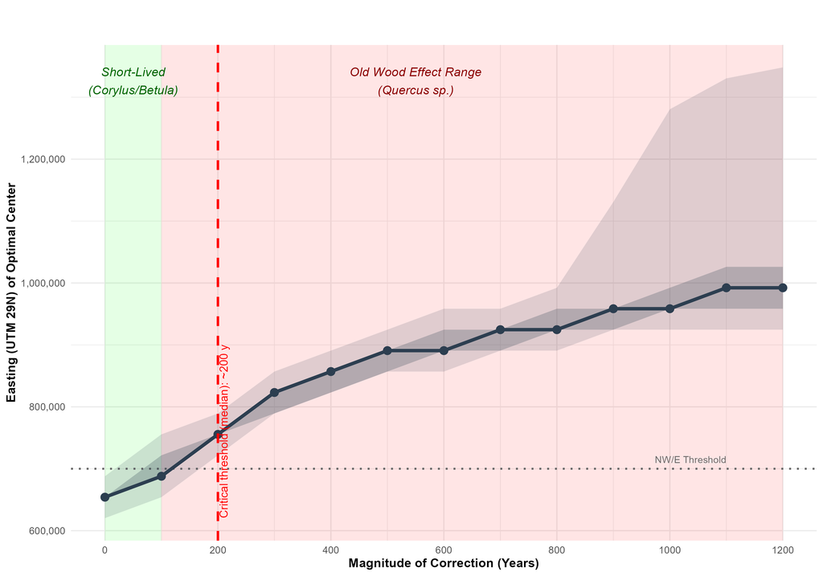

The results of the probabilistic estimates of regional megalithic phases in Iberia reveal a clear diachronous pattern in the adoption and consolidation of the megalithic complex (5).

**Code for Figure 5**

```r
# Figure 5. Trapezoidal model of Iberian megalith activity by region ----

# Load R packages ----
needed_packages <- c("oxcAAR", "here", "rcarbon")
install.packages(setdiff(needed_packages, rownames(installed.packages())),
                 repos = "https://cloud.r-project.org")
library(oxcAAR)
library(here)
library(rcarbon)

# Set OxCal path ----
oxcal_path <- here("OxCal", "bin", "OxCalWin.exe")
setOxcalExecutablePath(oxcal_path)

# Load custom functions ----
source(here("src", "oxcalScriptCreator.R"))
source(here("src", "oxcalParsing.R"))
source(here("src", "oxcalWorkflow.R"))

# Set output directories
dir.create(here("oxcalscripts"), showWarnings = FALSE)
dir.create(here("oxcalresults"), showWarnings = FALSE)
dir.create(here("figures"), showWarnings = FALSE)

# Set global parameters for the models
nsim <- 100000
region_names <- c("North", "East", "South", "Ebro basin", "Tagus basins", "Duero basins")

# Part 1. Load raw data and select the earliest date per site ----
dates   <- read.csv(here("data", "C14dates_Iberia_raw.csv"), sep = ";", na = "n/a")
dates   <- dates[dates$Excluded == "No", ]

# Calibrate all dates to filter by median calibrated age
dates_cal_all <- calibrate(
  x = dates$C14,
  errors = dates$STD,
  calCurves = "intcal20")
# Median calibrated age expressed as calendar BCE years
dates$MedianBCE <- summary(dates_cal_all)$MedianBP - 1950

# Exclude dates outside the 6000 BCE to 2500 BCE range (Neolithic, Chalcolitc to Bronze Age period)
dates <- dates[dates$MedianBCE >= 2500 & dates$MedianBCE <= 6000, ]

earliest <- do.call(rbind, lapply(split(dates, dates$Site), function(d)
  d[which.max(d$C14), , drop = FALSE]))
rownames(earliest) <- NULL
earliest$LabNumber <- make.unique(as.character(earliest$LabNumber))

# Part 2. Run one OxCal trapezoidal model per region ----
posteriors_list <- run_regional_trapezoid(
  region_names    = region_names,
  dates_earliest  = earliest,
  oxcal_path      = oxcal_path,
  scripts_dir     = here("oxcalscripts"),
  results_dir     = here("oxcalresults"),
  nsim            = nsim,
  n_cores         = 20,   # Threadripper PRO 7965WX: 20 dedicated physical cores
  force_recompute = TRUE)


# Convert to BCE and scale the results
to_bce <- function(v) -v # OxCal BC/AD to BCE
reScale <- function(x) # normalise to [0, 1]
  (x - min(x, na.rm = TRUE)) / (max(x, na.rm = TRUE) - min(x, na.rm = TRUE))

# Define a colour palette and graph labels
param_names <- c("onset", "peak", "decline", "disappear")

param_cols <- c(onset = "#2166ac", # first megalithic activity
                peak = "#1a9641", # peak use density
                decline = "#d7191c", # start of decline
                disappear = "#7b2d8b") # end of megalithic activity

param_labels <- c(onset = "Onset",
                  peak = "Peak density",
                  decline = "Decline",
                  disappear = "Disappear")

# Phase band height as fraction of the inter-region spacing (< 1 = no overlap)
phase_band_h <- 0.80

# Sort regions by median onset: earliest BCE at top, latest at bottom
onset_medians <- sapply(region_names, function(n) {
  vals <- to_bce(posteriors_list[[n]][["onset"]])
  median(vals[is.finite(vals)], na.rm = TRUE)
})
region_names <- region_names[order(onset_medians, decreasing = TRUE)]

# Pre-compute densities for each region and parameter
nreg     <- length(region_names)
dens_all <- vector("list", nreg)
names(dens_all) <- region_names

for (n in region_names) {
  bce <- lapply(posteriors_list[[n]], to_bce)
  dens_all[[n]] <- lapply(bce[param_names], function(v) {
    v <- v[is.finite(v)]
    density(v, adjust = 1.5, n = 1024)
  })
}

# Set the limits of the x axis
xlim_global <- c(2500, 6000)
at_major <- seq(6000, 2500, by = -500)
at_minor <- seq(6000, 2500, by = -100)

# Part 3. Make the plot (Figure 5) ----
png(file = here("figures", "Figure 5.png"),
    width = 2000, height = 1300, res = 130)
par(mar = c(5.5, 9, 5.5, 4),
    mgp = c(3, 1.4, 0),
    cex.axis = 1.15,
    cex.lab = 1.20,
    cex.main = 1.40)
plot(0, 0,
     xlim = rev(xlim_global),
     ylim = c(0.5, nreg + phase_band_h + 1.4),
     type = "n",
     xlab = "", ylab = "",
     axes = FALSE,
     main = "")

# X axis (bottom)
axis(1, at = at_major, labels = at_major, tck = -0.025, padj = -0.4)
axis(1, at = at_minor, labels = NA,       tck = -0.012)
mtext("BCE", side = 1, line = 3.2, cex = 1.2)

# X axis (top)
axis(3, at = at_major, labels = at_major, tck = -0.025, padj =  0.4)
axis(3, at = at_minor, labels = NA,       tck = -0.012)
mtext("BCE", side = 3, line = 3.2, cex = 1.2)

# Add Vertical lines connecting X axes
abline(v = seq(6000, 2500, by = -1000), col = adjustcolor("grey40", alpha.f = 0.3), lty = 3, lwd = 1.2)
abline(v = seq(6000, 2500, by = -500),  col = adjustcolor("grey60", alpha.f = 0.2), lty = 3, lwd = 0.6)

# Density of phases across regions
for (i in seq_along(region_names)) {
  n <- region_names[i]
  k <- nreg + 1 - i # reverse so region_names[1] is on top

  # Baseline for phase bands
  abline(h = k, col = "grey80", lty = 1, lwd = 0.7)
  region_dates <- earliest[earliest$Region == n, ]
  points(
    region_dates$MedianBCE,
    rep(k + 0.02, nrow(region_dates)),
    pch = 124,
    col = "black",
    cex = 0.65,
    lwd = 2,
    xpd = FALSE
  )

  for (p in param_names) {
    d <- dens_all[[n]][[p]]
    y_norm <- reScale(d$y) # normalise to [0, 1]
    y_top <- y_norm * phase_band_h + k # offset to phase band position
    y_base <- rep(k, length(d$y))

    # Fill the area under the curve
    polygon(c(d$x, rev(d$x)), c(y_top, y_base),
            col = adjustcolor(param_cols[p], alpha.f = 0.30),
            border = NA)
    # Create the density outline
    lines(d$x, y_top, col = param_cols[p], lwd = 2.0)

    # Add a median dot on the curve
    bce_vals <- to_bce(posteriors_list[[n]][[p]])
    med <- median(bce_vals[is.finite(bce_vals)], na.rm = TRUE)
    med_y <- approx(d$x, y_top, xout = med)$y
    points(med, med_y,
           pch = 21, bg = param_cols[p], col = "white",
           cex = 1.3, lwd = 1.6)
  }

  # Add the region labels on the left y axis
  mtext(n, side = 2, at = k, las = 2,
        line = 0.4, cex = 1.05, font = 2)
}

# Part 4. Add legend and schematic trapezoid ----

# 1. Create legend
leg_info <- legend(x = "topleft", inset = c(0.01, 0.01),
                   legend = param_labels,
                   col = param_cols,
                   lwd = 2.2, lty = 1,
                   pch = 21, pt.bg = param_cols, pt.cex = 1.3,
                   bty = "n", cex = 0.95)

# 2. Add the schematic trapezoid
# Calculate the shift needed to place the trapezoid just right of the legend
margin_bce <- 50
box_xleft <- leg_info$rect$left + leg_info$rect$w - margin_bce
shift_x <- box_xleft - 3850

# Place trapezoid at the same vertical level as the legend (centered within its box)
leg_mid    <- leg_info$rect$top - leg_info$rect$h / 2
sch_x      <- c(3600, 3450, 3150, 2750) + shift_x
sch_y_low  <- leg_mid - 0.30
sch_y_high <- leg_mid + 0.30


# Draw the trapezoid outline
lines(x = c(sch_x[1], sch_x[2], sch_x[3], sch_x[4], sch_x[1]),
      y = c(sch_y_low, sch_y_high, sch_y_high, sch_y_low, sch_y_low),
      col = "grey40", lwd = 1.2)

# Add the parameter dots
points(sch_x, c(sch_y_low, sch_y_high, sch_y_high, sch_y_low),
       pch = 21, bg = param_cols, col = "white", cex = 1.4, lwd = 1.5)

# Labels with same cex as standard legend (0.95)
text(sch_x[1], sch_y_low - 0.12, "Onset",     cex = 0.95, font = 3, adj = c(0.5, 1))
text(sch_x[2], sch_y_high + 0.12, "Peak",      cex = 0.95, font = 3, adj = c(0.5, 0))
text(sch_x[3], sch_y_high + 0.12, "Decline",   cex = 0.95, font = 3, adj = c(0.5, 0))
text(sch_x[4], sch_y_low - 0.12, "Disappear", cex = 0.95, font = 3, adj = c(0.5, 1))

box(bty = "o")
dev.off()

# Part 5. Save the summary table of posterior medians and 95% intervals ----
summary_table <- do.call(rbind, lapply(region_names, function(n) {
  row <- data.frame(Region = n)
  for (p in param_names) {
    vals <- to_bce(posteriors_list[[n]][[p]])
    vals <- vals[is.finite(vals)]
    row[[paste0(p, "_median")]] <- round(median(vals, na.rm = TRUE))
    row[[paste0(p, "_lo95")]] <- round(quantile(vals, 0.025, na.rm = TRUE))
    row[[paste0(p, "_hi95")]] <- round(quantile(vals, 0.975, na.rm = TRUE))
  }
  row$Amodel <- posteriors_list[[n]]$Amodel #includes the agreement index
  row
}))

write.csv(summary_table,
          file = here("esm", "Table_S2.csv"),
          row.names = FALSE)

# Session information for reproducibility
si <- sessionInfo()
print(si)
```

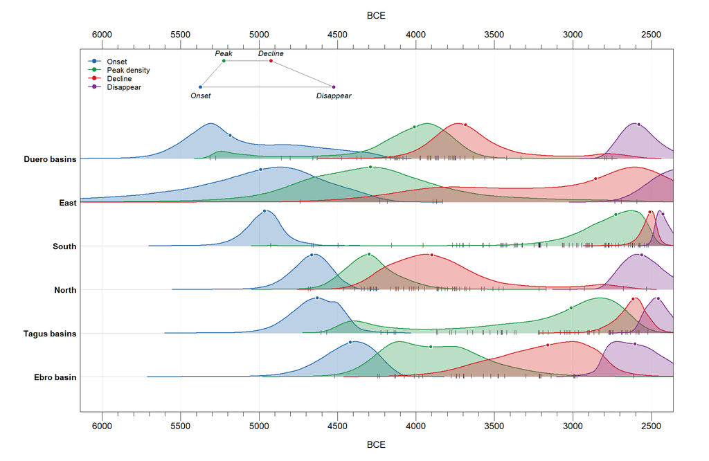

Figure 5: Probabilistic estimates of regional megalithic phases in Iberia. Posterior probability distributions for the four parameters of a trapezoidal model: onset (blue), peak (green), decline (red), and disappear (purple). Regions are ordered by the median posterior estimate of their onset boundary. The density plots represent the posterior probability distributions of each parameter. Dots indicate the posterior median estimated from 100,000 MCMC samples. Vertical ticks along each baseline indicate the median calibrated age of each radiocarbon sample included in the corresponding regional model.

The patterns observed in the regional Bayesian model also contrast with the results of our Iberian dispersal models (ESM Table S1). While the comparison based on all radiocarbon dates (raw models) points towards a primary Northwestern signal for the emergence of megalithic sites, this result is highly sensitive to the use of charcoal samples. When an “old wood effect” correction of -500 years is applied to charcoal dates of the North and Duero basins (where charcoal represents the 70-80% of the regional dates), the statistical center of gravity for the origin shifts significantly toward the interior of the Iberian Peninsula. This apparent tension between regional onsets and an Iberian trend can be explained by the different aspects of the phenomenon captured by each method. While the trapezoidal models are sensitive to early events, the quantile regression identifies the chronological gradient.

When the analysis is restricted to only human bone and teeth dates (n = 640; 61.1% of the dataset), a significantly different origin in the center-south interior is identified, specifically in the region encompassing Toledo, Ciudad Real, and northern Andalusia. Sites in the Tagus Basin are pivotal in this inland pull (ESM Table S1). For instance, the Dolmen of Azután (Toledo) and El Castillejo provide human bone dates as early as 4850-4300 BCE, a signal further anchored by another old human remains in the entire dataset: Cerro Virtud (Almería) at 5050-4650 BCE and Montelirio (Seville) at 4750-4550 BCE. It should be noted, however, that some of these monuments such as Azután are complex multi-period contexts, and these early dates should therefore be treated as provisional pending more systematic contextual and taphonomic review, rather than secure termini post quem for the onset of megalithic construction in the Tagus basin.

A potential source of uncertainty in dates derived from human remains is the marine reservoir effect, where marine-based diets can lead to uncalibrated ages appearing artificially older. While significant marine consumption could potentially bias spatial models in coastal territories, existing stable isotope research on Iberian megalithic individuals generally suggests a predominantly terrestrial diet (Dı́az-Zorita et al., 2019; Fontanals-Coll et al., 2017), with marine contributions appearing minor. In fact, 241 human bone remains in our dataset show a mean $\delta^{13}\text{C}$ value of -19.3‰ (max = -19.0‰), confirming a strictly terrestrial diet and ruling out any significant marine reservoir effect.

Consequently, a Northwestern origin model appears to be partially influenced by the potential old-wood bias of charcoal in that region. A bone-only model, supported by recent evidence from the Iberian Plateau (e.g., Valdelasilla site) (Barroso Bermejo et al., 2026) and the early megalithic clusters in the Duero and Tagus basins (e.g., Areita 1, Arquinha da Moura, Rego da Murta), suggests that the emergence of the megalithic phenomenon was not a unidirectional coastal diffusion but a multifocal process involving simultaneous developments across the Atlantic, the Mediterranean façades and the Iberian interior. In fact, regional comparisons between the bone/teeth trapezoidal models and the full radiocarbon dataset help visualising a picture like this (6, Table S3).

**Code for Figure 6**

```r
# Figure 6. Regional trapezoidal model comparison by material

# Load libraries
library(here)
library(oxcAAR)
library(rcarbon)

# Define colour palette (consistent with Figure 5)
param_cols <- c(
  onset     = "#2166ac",
  peak      = "#1a9641",
  decline   = "#d7191c",
  disappear = "#7b2d8b"
)
param_names  <- c("onset", "peak", "decline", "disappear")
param_labels <- c("Onset", "Peak", "Decline", "Disappear")
param_offsets <- c(onset = 0.35, peak = 0.12, decline = -0.12, disappear = -0.35)

all_regions <- c("North", "Duero basins", "East", "Ebro basin", "South", "Tagus basins")

# Minimum site threshold to run/plot a material subset
MIN_SITES <- 5

# --- Part 1. Setup OxCal paths and functions ---
oxcal_path <- here("OxCal", "bin", "OxCalWin.exe")
setOxcalExecutablePath(oxcal_path)

source(here("src", "oxcalScriptCreator.R"))
source(here("src", "oxcalParsing.R"))
source(here("src", "oxcalWorkflow.R"))

dir.create(here("oxcalresults", "bone_only"), showWarnings = FALSE, recursive = TRUE)
dir.create(here("oxcalscripts", "bone_only"), showWarnings = FALSE, recursive = TRUE)
dir.create(here("oxcalresults", "charcoal_only"), showWarnings = FALSE, recursive = TRUE)
dir.create(here("oxcalscripts", "charcoal_only"), showWarnings = FALSE, recursive = TRUE)

# --- Part 2. Load and filter dates ---
dates_raw <- read.csv(here("data", "C14dates_Iberia_raw.csv"), sep = ";", na = "n/a")
dates_raw <- dates_raw[dates_raw$Excluded == "No", ]

# Calibrate all dates to filter by median calibrated age (6000 BCE to 2500 BCE)
dates_cal <- calibrate(x = dates_raw$C14, errors = dates_raw$STD, calCurves = "intcal20")
dates_raw$MedianBCE <- summary(dates_cal)$MedianBP - 1950
dates_valid <- dates_raw[dates_raw$MedianBCE >= 2500 & dates_raw$MedianBCE <= 6000, ]

# Select earliest date per site
earliest_all <- do.call(rbind, lapply(split(dates_valid, dates_valid$Site), function(d) d[which.max(d$C14), , drop = FALSE]))
rownames(earliest_all) <- NULL
earliest_all$LabNumber <- make.unique(as.character(earliest_all$LabNumber))

# Subsets
bone_materials <- c("Human bone", "Animal bone", "Human teeth", "Bone", "Tooth")
earliest_bone <- earliest_all[earliest_all$Material %in% bone_materials, ]
earliest_char <- earliest_all[grepl("charcoal", earliest_all$Material, ignore.case = TRUE), ]

# Identify regions meeting the minimum sample size threshold
sites_bone_count <- table(earliest_bone$Region)
sites_char_count <- table(earliest_char$Region)

regions_bone_run <- names(sites_bone_count)[sites_bone_count >= MIN_SITES]
regions_char_run <- names(sites_char_count)[sites_char_count >= MIN_SITES]

# --- Part 3. Run regional trapezoidal models (Threadripper 20 cores) ---
# 1. Bone only
if (length(regions_bone_run) > 0) {
  run_regional_trapezoid(
    region_names    = regions_bone_run,
    dates_earliest  = earliest_bone,
    oxcal_path      = oxcal_path,
    scripts_dir     = here("oxcalscripts", "bone_only"),
    results_dir     = here("oxcalresults", "bone_only"),
    nsim            = 100000,
    n_cores         = 20,
    force_recompute = FALSE) # To recompute change this to TRUE
}

# 2. Charcoal only
if (length(regions_char_run) > 0) {
  run_regional_trapezoid(
    region_names    = regions_char_run,
    dates_earliest  = earliest_char,
    oxcal_path      = oxcal_path,
    scripts_dir     = here("oxcalscripts", "charcoal_only"),
    results_dir     = here("oxcalresults", "charcoal_only"),
    nsim            = 100000,
    n_cores         = 20,
    force_recompute = FALSE) # To recompute change this to TRUE
}

# 3. All dates
# Note: Already computed by Figure 5.R in oxcalresults/
run_regional_trapezoid(
  region_names    = all_regions,
  dates_earliest  = earliest_all,
  oxcal_path      = oxcal_path,
  scripts_dir     = here("oxcalscripts"),
  results_dir     = here("oxcalresults"),
  nsim            = 100000,
  n_cores         = 20,
  force_recompute = FALSE) # To recompute change this to TRUE

# --- Part 4. Load posteriors ---
to_bce <- function(v) -v

full_list <- list()
bone_list <- list()
char_list <- list()

for (reg in all_regions) {
  safe   <- gsub("[^A-Za-z0-9]", "_", reg)
  fname  <- paste0("trapezoid_regional_", safe, ".rds")
  fp_f   <- here("oxcalresults", fname)
  fp_b   <- here("oxcalresults", "bone_only", fname)
  fp_c   <- here("oxcalresults", "charcoal_only", fname)

  if (file.exists(fp_f)) full_list[[reg]] <- readRDS(fp_f)
  if (reg %in% regions_bone_run && file.exists(fp_b)) bone_list[[reg]] <- readRDS(fp_b)
  if (reg %in% regions_char_run && file.exists(fp_c)) char_list[[reg]] <- readRDS(fp_c)
}

# Quantile summary function
qstats <- function(post, param) {
  v <- to_bce(post[[param]])
  v <- v[is.finite(v)]
  c(lo95 = quantile(v, 0.025, names = FALSE),
    lo50 = quantile(v, 0.25,  names = FALSE),
    med  = median(v),
    hi50 = quantile(v, 0.75,  names = FALSE),
    hi95 = quantile(v, 0.975, names = FALSE))
}

# Sort regions by full-dataset onset median (earliest at top)
onset_med <- sapply(all_regions, function(r) {
  if (is.null(full_list[[r]])) return(NA)
  median(to_bce(full_list[[r]][["onset"]]), na.rm = TRUE)
})
regions_ord <- all_regions[order(onset_med, decreasing = TRUE)]
nreg <- length(regions_ord)

# Bar plotting helper
post.bar <- function(x, i, h, col) {
  # 95% HPDI
  rect(xleft = x["lo95"], xright = x["hi95"],
       ybottom = i - h/6, ytop = i + h/6,
       border = adjustcolor(col, 0.60), col = adjustcolor(col, 0.60), lwd = 0.5)
  # 50% HPDI
  rect(xleft = x["lo50"], xright = x["hi50"],
       ybottom = i - h/2.5, ytop = i + h/2.5,
       border = adjustcolor(col, 0.60), col = adjustcolor(col, 0.60), lwd = 0.5)
  # Median (grey vertical line)
  lines(c(x["med"], x["med"]), c(i - h/2, i + h/2),
        lwd = 2.2, col = "grey40")
}

# --- Part 5. Layout and Rendering ---
h_bar  <- 0.22
xlim_p <- c(6000, 2500)  # reversed: older dates on the left
at_maj <- seq(6000, 2500, by = -500)
at_min <- seq(6000, 2500, by = -100)

# Three bars per region:
# Upper: All dates
# Middle: Charcoal only
# Lower: Bone / teeth only
y_full_of <- function(ri) (nreg - ri + 1) * 3.8 + 0.9
y_char_of <- function(ri) (nreg - ri + 1) * 3.8
y_bone_of <- function(ri) (nreg - ri + 1) * 3.8 - 0.9
ylim_p    <- c(-3.2, nreg * 3.8 + 3.2)

png(file = here("figures", "Figure 6.png"),
    width = 1800, height = 1450, res = 160)

par(mar  = c(4.5, 9.5, 3.5, 1.5),
    mgp  = c(2.2, 0.7, 0),
    cex.axis = 0.95,
    cex.lab  = 1.05)

plot(NULL,
     xlim = xlim_p,
     ylim = ylim_p,
     xlab = "",
     ylab = "",
     axes = FALSE,
     main = "")

# Horizontal separators between regions
abline(h = seq(4.8, by = 3.8, length.out = nreg - 1),
       col = "darkgrey", lty = 2, lwd = 0.9)

# X axes
axis(1, at = at_maj, labels = at_maj, tck = -0.015, padj = -0.2)
axis(3, at = at_maj, labels = at_maj, tck = -0.015, padj =  0.2)
mtext("BCE", side = 1, line = 2.4, cex = 1.1)
mtext("BCE", side = 3, line = 1.9, cex = 1.1)

# Draw bars for each region
for (ri in seq_along(regions_ord)) {
  reg    <- regions_ord[ri]
  y_full <- y_full_of(ri)
  y_char <- y_char_of(ri)
  y_bone <- y_bone_of(ri)

  # 1. Full dataset (Combined + Charcoal Outlier model)
  if (!is.null(full_list[[reg]])) {
    for (p in param_names) {
      s <- qstats(full_list[[reg]], p)
      if (all(is.finite(s))) post.bar(s, y_full + param_offsets[p], h_bar, param_cols[p])
    }
  }

  # 2. Charcoal only (or blank if insufficient)
  if (!is.null(char_list[[reg]])) {
    for (p in param_names) {
      s <- qstats(char_list[[reg]], p)
      if (all(is.finite(s))) post.bar(s, y_char + param_offsets[p], h_bar, param_cols[p])
    }
  } else {
    text(4250, y_char, "(Insufficient charcoal data)", col = "grey65", cex = 0.75, font = 3)
  }

  # 3. Bone only (or blank if insufficient)
  if (!is.null(bone_list[[reg]])) {
    for (p in param_names) {
      s <- qstats(bone_list[[reg]], p)
      if (all(is.finite(s))) post.bar(s, y_bone + param_offsets[p], h_bar, param_cols[p])
    }
  } else {
    text(4250, y_bone, "(No bone data)", col = "grey65", cex = 0.75, font = 3)
  }

  # Region label on y-axis
  y_mid <- y_char
  mtext(reg, side = 2, at = y_mid, las = 2, line = 1.5, cex = 1.05, font = 2)
}

box(bty = "o", lwd = 1.2)

# Place dataset labels at bottom
ri_bottom <- nreg
text(5950, y_full_of(ri_bottom), "All dates", cex = 0.85, adj = 0, font = 1)
text(5950, y_char_of(ri_bottom), "Charcoal only",           cex = 0.85, adj = 0, font = 1)
text(5950, y_bone_of(ri_bottom), "Bone / teeth only",        cex = 0.85, adj = 0, font = 1)

# Legend HPDI scale bar
y0 <- -1.8
ex_x <- c(lo95=4900, lo50=4600, med=4300, hi50=3900, hi95=3400)
post.bar(ex_x, y0, 0.75, "grey60")

arrows(x0=ex_x["lo95"], x1=ex_x["hi95"], y0=y0 - 0.7, y1=y0 - 0.7, angle = 90, code = 3, length = 0.03, lwd = 1.2)
arrows(x0=ex_x["lo50"], x1=ex_x["hi50"], y0=y0 - 1.2, y1=y0 - 1.2, angle = 90, code = 3, length = 0.03, lwd = 1.2)

text(ex_x["lo95"] + 100, y0 - 0.7, "95% HPDI", cex = 0.75, adj = c(1, 0.5))
text(ex_x["lo50"] + 100, y0 - 1.2, "50% HPDI", cex = 0.75, adj = c(1, 0.5))

lines(c(ex_x["med"], ex_x["med"] + 200), c(y0 + 0.5, y0 + 1.2))
text(ex_x["med"] + 250, y0 + 1.2, "Median posterior", cex = 0.75, adj = c(1, 0.5))

# Legend Phase Parameters
legend(x = "bottomleft", inset = c(0.02, 0.02),
       legend = param_labels,
       fill   = adjustcolor(param_cols, 0.60),
       border = NA,
       bty    = "n",
       cex    = 0.95,
       title  = expression(bold("Phase parameter")))

dev.off()

# --- Part 6. Save comprehensive summary table (Table S3 in esm folder) ---
table_rows <- list()
for (reg in all_regions) {
  # 1. Full dates
  if (!is.null(full_list[[reg]])) {
    r_full <- data.frame(Region = reg, Dataset = "All dates (Charcoal outlier model)")
    for (p in param_names) {
      s <- qstats(full_list[[reg]], p)
      r_full[[paste0(p, "_median")]] <- round(s["med"])
      r_full[[paste0(p, "_lo95")]]   <- round(s["lo95"])
      r_full[[paste0(p, "_hi95")]]   <- round(s["hi95"])
    }
    r_full$Amodel <- full_list[[reg]]$Amodel
    table_rows[[length(table_rows) + 1]] <- r_full
  }

  # 2. Charcoal only
  if (!is.null(char_list[[reg]])) {
    r_char <- data.frame(Region = reg, Dataset = "Charcoal only")
    for (p in param_names) {
      s <- qstats(char_list[[reg]], p)
      r_char[[paste0(p, "_median")]] <- round(s["med"])
      r_char[[paste0(p, "_lo95")]]   <- round(s["lo95"])
      r_char[[paste0(p, "_hi95")]]   <- round(s["hi95"])
    }
    r_char$Amodel <- char_list[[reg]]$Amodel
    table_rows[[length(table_rows) + 1]] <- r_char
  }

  # 3. Bone dates
  if (!is.null(bone_list[[reg]])) {
    r_bone <- data.frame(Region = reg, Dataset = "Bone / teeth only")
    for (p in param_names) {
      s <- qstats(bone_list[[reg]], p)
      r_bone[[paste0(p, "_median")]] <- round(s["med"])
      r_bone[[paste0(p, "_lo95")]]   <- round(s["lo95"])
      r_bone[[paste0(p, "_hi95")]]   <- round(s["hi95"])
    }
    r_bone$Amodel <- bone_list[[reg]]$Amodel
    table_rows[[length(table_rows) + 1]] <- r_bone
  }
}

table_s3 <- do.call(rbind, table_rows)
write.csv(table_s3,
          file = here("esm", "Table_S3.csv"),
          row.names = FALSE)
```

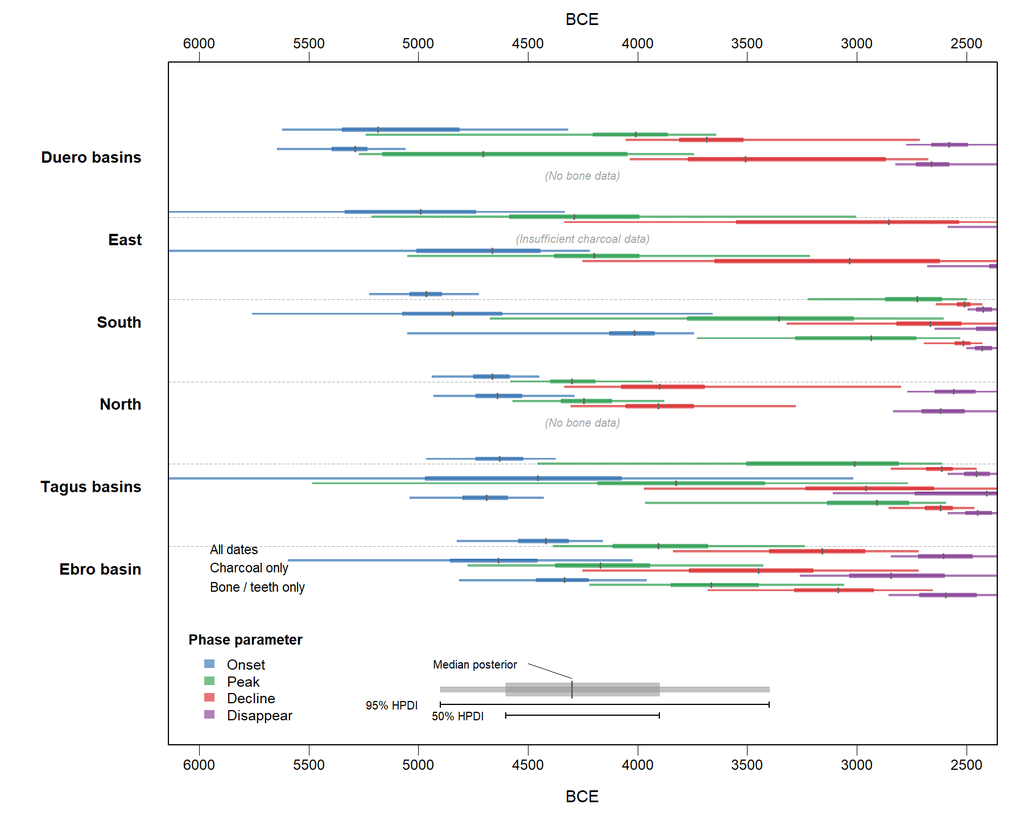

# 4 Discussion

The different regional manifestations of the Iberian megalithic phenomenon display a significant chronological overlap (Pardo-Gordó et al., 2020). The northwestern origin suggested by 3 should be treated with caution. These results likely reflect old-wood effects rather than real chronological trends. We must also distinguish between the statistical origin identifying the best age-distance relationship and the actual archaeological starting point, as our models primarily tested the single-source hypothesis as a heuristic tool for bias. The old-wood effect might be supported by the identification of *Quercus* sp. trunks burnt in Neolithic and Bronze Age funerary contexts of this area (Martín-Seijo et al., 2017; Vilas Boas & Martín-Seijo, 2014), whilst in hearths *Quercus* sp. twigs predominate (Martín-Seijo & Uzquiano, 2010).

A further interpretative warning concerns the uneven intensity of archaeological research across the Iberian Peninsula (see 2 A). Regions with longer traditions of systematic excavation, publication, and radiocarbon dating, particularly southern Iberia (Andalusia, Alentejo) and certain areas of the Meseta, are likely to be over-represented in our database relative to areas where research has been historically less systematic, such as the Ebro basin or inland Portugal. This differential research intensity may create apparent regional contrasts in the temporal density of radiocarbon dates that reflect sampling effort rather than genuine variation in the intensity of megalithic activity. While we cannot fully correct for this bias given the nature of the available data, we acknowledge it as a structural limitation of any model based on legacy radiocarbon databases and urge caution when interpreting inter-regional differences in the trapezoidal posteriors as direct proxies for the tempo of monument construction or cultural dynamics.

Based on the distributions in 5 and 6, the estimated onset of the megalithic phenomenon occurs earliest in the Duero basin, where a “latent phase” is visible from a posterior onset distribution spanning the mid-sixth to the fifth millennium BCE (95% CrI: 4320–5620 BCE; median: 5184 BCE, Table S2). Key sites contributing to this early signal include Outeiro de Ante 1 and 2, and Monte Maninho, all dated on charcoal samples. These sites, however, might present critical stratigraphic and taphonomic issues that need to be considered. As demonstrated in other prehistoric chronological debates (Pardo-Gordó, 2020), material type selection can introduce significant offsets where long-lived charcoal or animal/human remains diverge from short-lived samples like annual crops. In the context of burial monuments, human bone samples might be incorporating ancestral remains, as observed in some southeastern Iberian case studies (Aranda Jiménez et al., 2020; Dı́az-Zorita et al., 2019). In fact, a major relevant factor in raw radiocarbon datasets of megalithic sites is the distinction between sample material and context of origin: many early charcoal dates in NW Iberian megalithic contexts derive from mound fills or pre-mound paleosols, functioning as terminus post quem indicators. Pedological and chronological reviews of Northwestern Iberian megaliths (Bello Diéguez & Alonso Mathias, 1997; Cruz, 1992; Fábregas Valcarce, 1995; Fábregas Valcarce et al., 1997; Gómez Fernández, 2000) have long highlighted that organic matter and charcoal of pre-mound paleosols might be producing dates that reflect early vegetation activity prior to monument construction, creating chronometric offsets of up to a millennium relative to the subsequent architectural usages. In this vein, an inspection of the earliest radiocarbon dates in our database confirms this taphonomic pattern: dates such as OxA-1850 (6340±80 BP) and OxA-1848 (6150±80 BP) from Chã de Carvalhal 1, or Gif-8291 (6310±80 BP) from Outeiro de Ante 1, derive from pre-mound paleosols (ancient soil) rather than burial chambers. In the case of Chã de Carvalhal 1, as Cruz (1992) demonstrated, the primary use of this cistoid monument is actually associated with the Bell Beaker culture during the transition from the Late Chalcolithic to the Early Bronze Age, revealing a chronometric gap of over a millennium between the pre-mound paleosol charcoal pool and the actual monumental usage. In sites like Chã do Carvalhal 1, pre-construction soil decapitation exposed deeper, older soil charcoal pools, while mound construction incorporated redeposited soil charcoal (Cruz, 1992). Even in scenarios where pre-monument land clearance might involve short-lived shrub clearance (e.g., Ericaceae, Ulex) rather than primary oak forest, soil decapitation and redeposition could introduce severe substantial age offsets that can operate independently of taxonomic wood longevity.

On an alternative view, the early activity shown in 5 and 6 would find corroboration to some extent by the recent identification of monumental sites in the Tagus basin, such as Valdelasilla (Toledo), where Bayesian modelling confirms the establishment of burial chambers organized around central monuments by the end of the fifth millennium BCE (Barroso Bermejo et al., 2026). From the results of this paper, the exceptionally early median onset in the Duero basin must be interpreted within the generative logic of the trapezoidal model. It does not necessarily imply the existence of fully developed corridor chambers in the mid-6th millennium BCE but rather would identify early statistical tails of a “proto-megalithic” phase. Thus, it might be representing a period of regional funerary experimentations involving small-scale or earth-based structures that preceded the architectural consolidation of the phenomenon.

The regional alignment shown in 6 for areas with bone samples further refines this picture by demonstrating how sample selection affects these regional histories. In the Ebro basin, a comparison between the full radiocarbon dataset and the bone/teeth-only model reveals a somewhat earlier onset posterior (95% CrI: 4160-4824 BCE; median: 4420 BCE) than the bone/teeth baseline (95% CrI: 3960-4814 BCE; median: 4334 BCE). When the analysis is restricted to bone and teeth dates, prolonged intervals between the onset and peak posterior distributions emerge. In the Tagus basin, the bone/teeth baseline indicates an interval of approximately 1,700-1,800 years between the onset (95% CrI: 4430-5040 BCE; median: 4690 BCE) and the peak phase (95% CrI: 2594–3964 BCE; median: 2910 BCE), while the Ebro basin exhibits a comparable gap of approximately 700 years between equivalent parameters (peak 95% CrI: 3060–4220 BCE; median: 3664 BCE).

As a complement, to address whether this material-type bias could be a true physical effect or the result of contextual variation (i.e. bone from chambers versus charcoal from infra-mound paleosols), we compared dates recovered only from burial chambers. The result model (see ESM 2, Figure B) demonstrates that charcoal samples recovered inside burial chambers still systematically push estimated regional onsets towards older chronologies. In the Duero basin, chamber charcoal dates throw a median onset of 5294 BCE compared to 4720 BCE for chamber bone/teeth dates, a shift of nearly 570 years causing the combined chamber model to remain aged at 5124 BCE. In contrast, in regions with abundant human skeletal remains such as the Tagus basin and the South, chamber bone/teeth dates anchor the onset at 3740 BCE and 4004 BCE respectively, confirming that material-type bias acts directly within the funerary chamber itself rather than merely being an artefact of mound or paleosol sampling.

This pattern is consistent with recent proposals for the local development of “proto-megalithic” traditions across Iberia, whereby incipient monumentality gradually evolved into more complex funerary forms (García Sanjuán et al., 2022). Similar transitions are documented in southern Iberia at Campo de Hockey (Cádiz), where funerary practices range from simple burial pits to megalithic tombs (Vijande Vila, 2009, 2015), and may also characterize the northeastern regions, as suggested by the early cists of the Tavertet area in Catalonia (Gibaja Bao et al., 2010; Molist, 1987). Thus, an interesting picture would imagine that while the Mediterranean coast experienced some sporadic, early “maritime” pioneering events, the definitive expansion of the phenomenon in eastern and inland Iberia was a later, maybe a more coordinated process that followed an Atlantic momentum.

This possible early phase was not limited to the interior. Well-documented sites like Tomb 11 at Campo de Hockey (Cádiz) and Arroyo Saladillo (Antequera) demonstrate small-scale architectural solutions that clearly anticipate subsequent expansions. Those ideas, dated mainly in the transit from the 6th to the mid-5th millennium BCE, provided a cultural “breeding ground” upon which the corridor-chamber phenomenon would later crystallise, suggesting that Iberian monumentality emerged from a complex interplay between indigenous evolution and the arrival of foreign ideas. Of course, accepting a model of internal development of Iberian megaliths does not mean that other external factors should not be considered. In Atlantic contexts, recent research has highlighted that regions such as northern Portugal, Galicia, and Asturias may have been well connected with areas of innovation in France during the Neolithic and Chalcolithic periods. Accepting possible external influences does not exclude the role of internal dynamics, such as settlement patterns, long-term interaction between indigenous populations and incoming Neolithic groups (Martiniano et al., 2017; Scarre, 2020), or processes where population movement played a key role (Carvalho, 2016). The latter idea is further supported by spatial analyses in several Atlantic regions, which show that megalithic sites are frequently located near natural transit routes, crossing areas of everyday activity while also forming part of regional and long-distance networks, both terrestrial and maritime (Carrero-Pazos et al., 2018; Carrero-Pazos et al., 2019; Llobera, 2015; Martinón-Torres, 2001; Murrieta-Flores et al., 2012; Rodríguez-Rellán et al., 2019). Additional support for population mobility comes from ancient DNA studies, which suggest that Neolithic builders in Europe were part of closely related communities (Sánchez-Quinto et al., 2019). This genetic proximity likely also reflects the existence of far-reaching kinship networks that facilitated the rapid transmission of megalithic architectural and symbolic practices across the Atlantic façade.

Consequently, dual models combining Mesolithic-rooted innovations with external practices may be offering parsimonious explanations for Iberia. This perspective accounts for the architectural and artistic similarities between Atlantic passage graves, as well as the high density of dolmens in the Iberian Northwest compared to the relative scarcity of other megalithic forms, such as menhirs or stone circles (Cassen, 2012). It also explains the widespread reuse of monuments where larger passage graves were superimposed on smaller, pre-existing structures (López-Romero, 2017), a process of spatial appropriation documented at sites like Dombate in Galicia (Bello Diéguez, 1991, 1996).

Finally, we also want to mention a methodological issue concerning the spatial diffusion models developed in this work. In 3 and 4, dates were first calibrated and then assessed using spatial quantile regressions over a geographic grid, with the calibration uncertainties being propagated by means of Monte Carlo resampling. In this context, a promising area for future research would be the development of an integrated spatio-temporal Bayesian model. This would allow the calibration of dates and the estimation of the spatial spread parameters to be carried out within a single likelihood. At present, however, the Monte Carlo sensitivity approach carried out here was conceived as a practical analysis which allowed us to demonstrate that an apparent Northwestern origin remains extraordinarily fragile when faced with realistic old-wood offsets.

# 5 Conclusion

This study has demonstrated that material-type bias can seriously impact statistical models of cultural origin and spread. A comprehensive analysis of over 1,000 dates from 337 megalithic sites indicates that an initially apparent northwestern origin identified by uncorrected spatial models cannot be defended. Sensitivity analyses showed that applying age offsets of 100-300 years was sufficient to alter the inferred spatial origin of the megalithic phenomenon. This magnitude of offset falls within the expected age range of long-lived *Quercus* sp., which dominate the charcoal assemblages in Atlantic Iberia, indicating that the apparent northwestern origin is not robust to plausible old-wood effects. Although the stratigraphic context of samples, such as the burial chamber or the mound fill could potentially introduce chronological offsets, the analyses restricted to samples from chambers helps confirming that charcoal still offers older estimates than the bone/teeth from the same context. This supports the interpretation that the material type itself is a primary driver of the bias, although the context bias must not be ruled out.

Rather than a single-source diffusion, our results also support a polycentric and convergent model, as recent research have pointed out (Barroso Bermejo et al., 2026; García Sanjuán et al., 2022). The data suggests multiple independent focal points of funerary trends across the Duero, Tagus, and southern basins, which subsequently converged into a consistent and interconnected phenomenon during the early 4th millennium BCE. Furthermore, our regional comparative models demonstrate that systematically contrasting bone/teeth-only baselines against full radiocarbon datasets reveals consistent directional biases in regions dominated by charcoal samples, and that more robust regional sequences can be recovered when material-type biases are explicitly accounted for.

Beyond the Iberian context, the methodological framework developed here, combining quantile regression, sensitivity analysis, and probability density mapping, provides a robust assessment of chronological bias in georeferenced radiocarbon datasets. Such interpretation of legacy radiocarbon information clearly needs now to be combined with systematic dating programs, including new radiocarbon on seeds and single-grain optically stimulated luminescence for regions where acidic soils limit recovery of bone samples and more routine attention to the risk of human bone marine dietary offsets.

# 6 Data availability

This research was conducted with a view to reproducibility and replicability (Marwick, 2017) using OxCal (Bronk Ramsey, 1995; Hinz et al., 2018) and the R statistical environment (R Core Team, 2020), within RStudio Version 1.3.959, and making use of several specialist packages, namely *rcarbon* 1.4.1 (Crema & Bevan, 2021) and *spatstat* (Baddeley & Turner, 2005), with some AI-based support for code development, particularly for polishing.

The archaeological data and R scripts for reproducing all the analyses is publicly available in a Zenodo repository (https://zenodo.org/records/21772034) under CC BY 4.0 (data) and the MIT license (code). In addition, a Github repository is maintained for collaborative work and code versioning (https://github.com/mcarreropazos/IberianMegaliths). We also provide a reproducible Quarto manuscript that enables readers to regenerate all analyses, figures, and tables presented in this study, and an interactive Binder environment (https://mybinder.org/v2/gh/MCarreroPazos/IberianMegaliths/main?urlpath=rstudio).

# 7 References

Alday Ruiz, A., & Mejías-García, J. C. (2019). La cronología de la prehistoria de la península ibérica y los sistemas de información geográfica del registro arqueológico. *Cuadernos de Prehistoria y Arqueología*, *45*, 9–26.

Aranda Jiménez, G., Díaz-Zorita Bonilla, M., Robles Carrasco, S., & Sánchez Romero, M. (2020). Chronology and depositional dynamics of human remains in ditched enclosures: The case of marroquíes bajos (jaén, spain). *European Journal of Archaeology*, *23*(4), 512–535.

Aranda Jiménez, G., & Lozano Medina, Á. (2015). CronoloGEA: A 14C database for the prehistory of the southern half of the iberian peninsula. *Radiocarbon*, *57*(5), 1–11.

Baddeley, A., Rubak, E., & Turner, R. (2016). *Spatial point patterns: Methodology and applications with r*. CRC press.

Baddeley, A., & Turner, R. (2005). Spatstat: An r package for analyzing spatial point patterns. *Journal of Statistical Software*, *12*, 1–42.

Barroso Bermejo, R., Bueno-Ramírez, P., Cerrillo-Cuenca, E., Martínez-Sevilla, F., Sáez Martínez, M., Cambra-Moo, O., Rojas Rodríguez-Malo, J. M., Castañeda Clemente, N., Díaz-Zorita Bonilla, M., Moraga Vaz, P., Vicente Navarro, A., Altamirano García, M., & Alvarez-Fernández, E. (2026). New dates for the emergence of the megalithic phenomenon on the iberian plateau: The funerary practices of valdelasilla, toledo (spain). *Cambridge Archaeological Journal*, 1–19. https://doi.org/10.1017/S0959774326100559

Bello Diéguez, J. M. (1991). Monumento megalítico de dombate (cabana, a coruña). Primeiros resultados. *Arqueoloxía-Informes*, *2*, 21–27.

Bello Diéguez, J. M. (1996). *O dolmen de dombate*. Diputación Provincial de A Coruña.

Bello Diéguez, J. M., & Alonso Mathias, F. (1997). Cronología y periodización del fenómeno megalítico en galicia a la luz de las dataciones por carbono 14. In A. A. Rodríguez Casal (Ed.), *O neolítico atlántico e as orixes do megalitismo: Actas do coloquio internacional* (pp. 507–520). Universidade de Santiago de Compostela.

Bosch, A., Buxó, R., Palomo, A., Buch, M., Mateu, J., Tabernero, E., & Casanova, J. (2020). Variscite source and source analysis: Gavà and palazuelo de las cuevas mines (NE and NW spain). *Comptes Rendus Palevol*, *19*(8), 159–174.

Bosch-Gimpera, P. (1925). El problema etnológico vasco y la arqueología. *Revista Internacional de Estudios Vascos*, *16*, 588–596.

Bradley, R. (1998). *The significance of monuments: On the shaping of human experience in neolithic and bronze age europe*. Routledge.

Bronk Ramsey, C. (1995). Radiocarbon calibration and analysis of stratigraphy: The OxCal program. *Radiocarbon*, *37*(2), 425–430.

Bronk Ramsey, C. (2009). Bayesian analysis of radiocarbon dates. *Radiocarbon*, *51*(1), 337–360.

Bueno Ramírez, P., Balbín Behrmann, R. de, & Barroso Bermejo, R. (2012). Grafías en el paisaje. El arte megalítico en el centro de la península ibérica. *Menga: Revista de Prehistoria de Andalucía*, *3*, 13–72.

Bueno Ramírez, P., Balbín Behrmann, R. de, & Barroso Bermejo, R. (2016). Menhires ibéricos: Una visión actualizada. *Boletín Del Seminario de Estudios de Arte y Arqueología*, *82*, 9–77.

Burnham, K. P., & Anderson, D. R. (2002). Model selection and multimodel inference: A practical information-theoretic approach. *Springer Science & Business Media*.

Callaghan, R., & Cooney, G. (2009). The origins and development of the irish neolithic in the context of the western european neolithic. *The Irish Stone Axe Project*, 1–11.

Carrero-Pazos, M., Bevan, A., & Lake, M. W. (2019). Locational preferences and spatial arrangement in the barrow landscape of serra do barbanza (north-western iberia). *Journal of Archaeological Science*, *108*, 104968.

Carrero-Pazos, M., Vilas-Estévez, B., & Vázquez-Martínez, A. (2018). Locational preferences and spatial arrangement in the barrow landscape of serra do barbanza (north-western iberia). *Journal of Archaeological Science: Reports*, *31*, 102351.

Carvalho, A. F. (2010). Chronology and geography of the mesolithic-neolithic transition in portugal. *The Neolithisation of the Iberian Peninsula*, 57–72.

Carvalho, A. F. (2016). The mesolithic-neolithic transition in southern iberia. *Quaternary International*, *403*, 31–49.

Case, H. (1969). Neolithic explanations. *Antiquity*, *43*(171), 176–186.

Cassen, S. (2012). Architectures funéraires et statues-menhirs dans le néolithique de l’ouest de la france. *Statues-Menhirs Et Pierres Levées Du Néolithique à Aujourd’hui*, 89–110.

Cassen, S. (2015). Corpus des signes gravés néolithiques. *Bulletin de La Société Préhistorique Française*, *112*(3), 517–576.

Cassen, S., & Grimaud, V. (2019). Neolithic atlantic art: A world apart? *World Art*, *9*(2), 117–142.

Cassen, S., Lanos, P., Dufresne, P., Oberlin, C., Delqué-Količ, E., & Le Goffic, M. (2009). Autour de la table. Explorations archéologiques et discours savants sur des architectures néolithiques à locmariaquer, morbihan (table des marchands et grand menhir). *Actes Du Colloque International de Vannes*.

Cassidy, L. M., Martiniano, R., Murphy, E. M., Teasdale, M. D., Mallory, J., Hartwell, B., & Bradley, D. G. (2016). Neolithic and bronze age migration to ireland and establishment of the insular atlantic genome. *Proceedings of the National Academy of Sciences*, *113*(2), 368–373.

Crema, E. R., & Bevan, A. (2021). Inference from large sets of radiocarbon dates: Software and methods. *Radiocarbon*, *63*(1), 23–39.

Crema, E. R., & Kobayashi, K. (2020). A multi-proxy inference of jōmon population dynamics using bayesian phase models, residential data, and summed probability distribution of 14C dates. *Journal of Archaeological Science*, *117*, 105136. https://doi.org/10.1016/j.jas.2020.105136

Cruz, D. J. da. (1992). *A mamoa 1 de chã de carvalhal no contexto arqueológico da serra da aboboreira*. Lucerna / Conimbriga (Anexos I).

Cunliffe, B. (2001). *Facing the ocean: The atlantic and its peoples, 8000 BC-AD 1500*. Oxford University Press.

De la Fuente Andrés, F. (1994). El fenómeno megalítico en cantabria: Aproximación a través de las últimas investigaciones. *Kobie*, *21*, 39–50.

Dı́az-Zorita, M., Aranda Jiménez, G., Bocherens, H., Escudero, J., Sánchez Romero, M., Alarcón, E., & Milesi, L. (2019). Multi-isotopic diet analysis of south-eastern iberian megalithic populations: The cemeteries of el barranquete and panorı́a. *Archaeological and Anthropological Sciences*, *11*, 3681–3698.

Fábregas Valcarce, R. (1995). La realidad funeraria en el noroeste del neolítico a la edad del bronce. In C. Fernández Ibáñez, F. Pérez Losada, & R. Fábregas Valcarce (Eds.), *Arqueoloxía da morte* (pp. 95–125). Concello de Xinzo de Limia.

Fábregas Valcarce, R., Fernández Rodríguez, C., & Ramil Rego, P. (1997). La adopción de la economía productora en el noroeste ibérico. In A. A. Rodríguez Casal (Ed.), *O neolítico atlántico e as orixes do megalitismo: Actas do coloquio internacional* (pp. 463–484). Universidade de Santiago de Compostela.

Fábregas Valcarce, R., & Rodríguez-Rellán, C. (2012). Las grandes hachas de jadeíta alpina en el noroeste de la península ibérica. *Rubricatum: Revista Del Museu de Gavà*, *5*, 283–288.

Fontanals-Coll, M., Eulàlia Subirà, M., Dı́az-Zorita Bonilla, M., & Gibaja, J. F. (2017). First insight into the neolithic subsistence economy in the north-east iberian peninsula: Paleodietary reconstruction through stable isotopes. *American Journal of Biological Anthropology*, *162*(1), 36–50.

Forde, C. D. (1930). Early cultures of atlantic europe. *American Anthropologist*, *32*(1), 19–100.

García Sanjuán, L., Cintas-Peña, M., Díaz-Guardamino, M., Escacena Carrasco, J. L., Wheatley, D. W., Rodríguez Vidal, J., Bartelheim, M., Luciañez Triviño, M., Mora Molina, C., & Robles Carrasco, S. (2020). Assembling the dead, gathering the living: Radiocarbon dating and bayesian modelling for copper age valencina de la concepción (sevilla, spain). *Journal of World Prehistory*, *33*, 179–313.

García Sanjuán, L., Cintas-Peña, M., Díaz-Guardamino, M., Escacena Carrasco, J. L., Wheatley, D. W., Rodríguez Vidal, J., Bartelheim, M., Luciañez Triviño, M., Mora Molina, C., Robles Carrasco, S., et al. (2022). Chronology, temporality and social dynamics in iberian megalithic monuments: Recent radiocarbon research at palacio III, montelirio and la pijotilla (southern spain). *Radiocarbon*, *64*(4), 1–40.

Gavilán Ceballos, B., & Vera Rodríguez, J. C. (2005). La cronología absoluta del megalitismo andaluz. Revisión crítica de las dataciones C14 de los sepulcros megalíticos de andalucía. *Menga: Revista de Prehistoria de Andalucía*, *1*, 81–98.

Gibaja Bao, J. F., Subirà de Galdàcano, M. E., & Terradas, X. (2010). Prácticas funerarias durante el neolítico. Los enterramientos infantiles en el noreste de la península ibérica. *Complutum*, *21*(2), 47–68.

Gómez Fernández, A. (2000). La adopción de la economía productora en el noroeste peninsular: Información polínica y paleocarpológica. *Cátedra. Revista Eumesa de Estudios*, *7*, 67–94.

Hinz, M., Schmid, C., Knitter, D., & Tietze, C. (2018). oxcAAR: Interface to ’OxCal’ radiocarbon calibration. *R Package Version*, *1*, 0.

Laporte, L., & Tinevez, J.-Y. (2010). Megalithic architectures in atlantic europe: Origins, main features and evolution. *Munibe Antropologia-Arkeologia*, *61*, 127–148.

Lee, S., & Ramsey, C. B. (2012). Development and application of the trapezoidal model for archaeological chronologies. *Radiocarbon*, *54*(1), 107–122.

Leisner, G., & Leisner, V. (1938). *Die megalithgräber der iberischen halbinsel: Der süden*. Walter de Gruyter.

Leisner, V. (1965). *Die megalithgräber der iberischen halbinsel: Der westen*. Walter de Gruyter.

Lillios, K. T. (2019). *The archaeology of the iberian peninsula: From the paleolithic to the bronze age*. Cambridge University Press.

Linares Catela, J. A. (2022). Radiocarbon chronology of dolmens in the iberian southwest: Architectural sequence and temporality in the el pozuelo megalithic complex (huelva, spain). *Radiocarbon*, *64*(5), 989–1064. https://doi.org/10.1017/RDC.2022.48

Llobera, M. (2015). Working the digital: Some thoughts from landscape archaeology. *Mobility, Transition and Change in Prehistory and Classical Antiquity*, 173–188.

López-Romero, E. (2017). Celticism, chronology and megalithic tombs: A comment on rodríguez-rellán et al. *Oxford Journal of Archaeology*, *36*(4), 435–440.

Mañana-Borrazás, P., Blanco-Chao, R., & Rodríguez-Paz, A. (2005). Túmulo 5 de forno dos mouros (ortigueira, a coruña). Primeiros resultados. *Cuadernos de Estudios Gallegos*, *52*(118), 39–79.

Martiniano, R., Cassidy, L. M., Ó’Maoldúin, R., McLaughlin, R., Silva, N. M., Manco, L., Fidalgo, D., Pereira, T., Coelho, M. J., Serra, M., et al. (2017). The population genomics of archaeological transition in west iberia: Investigation of ancient substructure using imputation and haplotype-based methods. *PLoS Genetics*, *13*(7), e1006852.

Martinón-Torres, M. (2001). De la caza al metal. Cambio tecnológico y contacto cultural en la prehistoria de galicia. *Brigantium*, *13*, 113–124.

Martín-Seijo, M., Liz, P. V., & Prieto-Martínez, M. P. (2017). Estudio antracológico de a devesa de abaixo (pontevedra): Un espacio funerario atípico de la prehistoria del NW de iberia. *Estudos Do Quaternário / Quaternary Studies*, (16), 17–29.

Martín-Seijo, M., & Uzquiano, P. (2010). Análisis antracológico de estructuras de combustión neolíticas en el noroeste peninsular: Porto dos valos, a gándara y monte dos remedios (provincia de pontevedra, galicia). In *Variações paleoambientais e evolução antrópica no quaternário do ocidente peninsular* (pp. 125–132). APEQ-CITCEM.

Marwick, B. (2017). Computational reproducibility in archaeological research: Basic principles and a case study of their implementation. *Journal of Archaeological Method and Theory*, *24*(2), 424–450.

Midgley, M. S. (2005). *The monumental cemeteries of prehistoric europe*. Tempus.

Molist, M. (1987). Los sepulcros megalíticos de fosa de la comarca de osona, barcelona. *Trabajos de Prehistoria*, *44*, 213–234.

Molist, M., Clop, X., Gibaja, J. F., Martín, P., Pou, R., & Saña, M. (2010). Ocupaciones neolíticas en el interior de cataluña: Una aproximación al poblamiento en el VI milenio cal BC. *Munibe Antropologia-Arkeologia*, *61*, 173–197.

Morell Rovira, B., Clop García, X., Martínez Grau, H., Mora González, R., Palomo Pérez, A., Pou Vallès, J. M., & Terradas Batlle, X. (2018). La tomba del segudet (ordino, andorra): Un enterrament del neolític antic pirinenc. *Tribuna d’Arqueologia*, 9–32.

Müller, J. (2014). 4100–2700 b.c. Monuments and ideologies in the neolithic landscape. In J. F. Osborne (Ed.), *Approaching monumentality in archaeology* (pp. 181–214). State University of New York Press.

Muñoz Ibáñez, F. J. (2021). Megalithic tombs and social complexity in neolithic iberia. *Journal of World Prehistory*, *34*, 1–52.

Murrieta-Flores, P., Wheatley, D. W., & García Sanjuán, L. (2012). Understanding human movement through spatial technologies. The role of natural areas of transit in the late prehistory of south-western iberia. *Trabajos de Prehistoria*, *69*(1), 103–122.

Pardo-Gordó, S. (2020). ¿Efecto de los huesos de ovicaprinos domésticos en las fechas radiocarbónicas?: Un primer ensayo metodológico a partir de los datos disponibles en relación con las primeras sociedades neolíticas de la península ibérica. *Archivo de Prehistoria Levantina*, *33*, 55–76.

Pardo-Gordó, S., Carvalho, A. F., & Berrocal, M. C. (2020). Chronology and demography of the iberian megalithic phenomenon: A bayesian approach. *Journal of Archaeological Science*, *122*, 105226.

Pétrequin, P., Cassen, S., Errera, M., Klassen, L., Sheridan, A., & Pétrequin, A.-M. (2012). Jade. Grandes haches alpines du néolithique européen. Ve et IVe millénaires av. J.-c. *Presses Universitaires de Franche-Comté*.

R Core Team. (2020). *R: A language and environment for statistical computing*. R Foundation for Statistical Computing. https://www.R-project.org/

Reimer, P. J., Austin, W. E., Bard, E., Bayliss, A., Blackwell, P. G., Bronk Ramsey, C., Butzin, M., Cheng, H., Edwards, R. L., Friedrich, M., et al. (2020). The IntCal20 northern hemisphere radiocarbon age calibration curve (0–55 cal kBP). *Radiocarbon*, *62*(4), 725–757.

Renfrew, C. (1973). *Before civilization: The radiocarbon revolution and prehistoric europe*. Jonathan Cape.

Renfrew, C. (1976). *Before civilization*. Penguin Books.

Rodríguez-Rellán, C., Fábregas Valcarce, R., & Carrero-Pazos, M. (2019). Stonehenge and other british monuments in the light of the iberian megalithic tradition. *Oxford Journal of Archaeology*, *38*(2), 176–193.

Rodríguez-Rellán, C., Fábregas Valcarce, R., Carrero-Pazos, M., Peña Santos, A. de la, Pétrequin, P., & Errera, M. (2020). Circulation of jadeitite axes in north-western iberia during the neolithic: New data from the ulla river basin (galicia, spain). *European Journal of Archaeology*, *23*(1), 3–26.

Sánchez-Quinto, F., Malmström, H., Fraser, M., Girdland-Flink, L., Svensson, E. M., Simões, L. G., George, R., Hollfelder, N., Burenhult, G., Noble, G., et al. (2019). Megalithic tombs in western and northern neolithic europe were linked to a kindred society. *Proceedings of the National Academy of Sciences*, *116*(19), 9469–9474.

Santa Cruz, A. (2024). Chronological study of collective burials in the northern iberian plateau: Analysis and bayesian models. *Radiocarbon*, *66*(1), 155–204. https://doi.org/10.1017/RDC.2024.19

Scarre, C. (2011). *Landscapes of neolithic brittany*. Oxford University Press.

Scarre, C. (2020). *The oxford handbook of the archaeology and anthropology of rock art*. Oxford University Press.

Schulz Paulsson, B. (2017). Time and stone: The emergence and development of megaliths and megalithic societies in europe. *BAR International Series*, *2409*.

Schulz Paulsson, B. (2019). Radiocarbon dates and bayesian modeling support maritime diffusion model for megaliths in europe. *Proceedings of the National Academy of Sciences*, *116*(9), 3460–3465.

Sheridan, A. (2010). The neolithization of britain and ireland: The ’big picture’. *Landscapes in Transition*, 89–105.

Silva, F., Stevens, C. J., Weisskopf, A., Castillo, C., Qin, L., Bevan, A., & Fuller, D. Q. (2015). Modelling the geographical origin of rice cultivation in asia using the rice archaeological database. *PLoS ONE*, *10*, e0137024.

Soares, J. (2000). Radiocarbon dating of the portuguese neolithic. *Muita Gente, Poucas Antas? Origens, Espaços e Contextos Do Megalitismo*, 31–42.

Towner, M. C., & Luttbeg, B. (2007). Assessing the performance of the likelihood ratio test for comparing AIC values. *Behavioral Ecology and Sociobiology*, *61*(5), 679–685.

Uriarte González, A. (2017). IDEArqC14: Una infraestructura de datos espaciales para las dataciones radiocarbónicas de la prehistoria reciente del país vasco. *Munibe Antropologia-Arkeologia*, *68*, 273–284.

Vijande Vila, E. (2009). El asentamiento de campo de hockey (san fernando, cádiz): Resultados preliminares y líneas de investigación futuras para el conocimiento de las formaciones sociales tribales en la bahía de cádiz (tránsito v-IV milenios a.n.e.). *Revista Atlántica-Mediterránea de Prehistoria y Arqueología Social*, *11*, 265–284.

Vijande Vila, E. (2015). Sociedades tribales en el origen del neolítico andaluz. El asentamiento de campo de hockey (san fernando, cádiz). In *Actas del i congreso de prehistoria de andalucía. La tutela del patrimonio prehistórico* (pp. 187–192). Junta de Andalucía.

Vilas Boas, L., & Martín-Seijo, M. (2014). Ritos de fogo em contextos funerários da idade do bronze do NW da ibéria: O caso de estudo do monumento sob tumulus de vale de chão 1 (braga, portugal). In A. M. S. Bettencourt, B. Comendador Rey, H. A. Sampaio, & E. Sá (Eds.), *Corpos e metais na fachada atlântica da ibéria. Do neolítico à idade do bronze* (pp. 39–47). APEQ, CITCEM.

Zilhão, J. (2001). Radiocarbon evidence for maritime pioneer colonization at the origins of farming in west mediterranean europe. *Proceedings of the National Academy of Sciences*, *98*(24), 14180–14185.

# 8 Acknowledgments

The authors are grateful to Antón A. Rodríguez Casal for some of the photographs of Figure 1 and to Enrique Cerrillo for his insightful comments on an earlier version of this manuscript. They also wish to thank Reviewer 1 and Dr. Rowan McLaughlin (Reviewer 2) for their constructive suggestions, which substantially contributed to improving the final version of this paper. The lead author’s contribution to this research was in part supported by a Marie Sklodowska-Curie grant (reference 886793) hosted at the UCL Institute of Archaeology, and by the projects “Detección automática de monumentos tumulares e megalíticos mediante tecnoloxía LiDAR e Intelixencia Artificial (DISCOVER)” (USC 2025-PU014, PI: Miguel Carrero Pazos), “Paisajes Megalíticos: Explorando los factores humanos y ambientales de las sociedades neolíticas en el noroeste de la Península Ibérica (V-II milenio a.C.) (MegaLands)”, PID2024-156264NA-I00 funded by MICIU/AEI/10.13039/501100011033/ FEDER, UE (PI: Miguel Carrero Pazos, Noemí Silva Sánchez).

# 9 Ethics and data statement

No permits were required for the described study, which complied with all relevant regulations. There were no new excavations made, and the authors did not perform any intervening, or destructive sampling of human or archaeological remains. All data analysed was taken from previously published work and consisted of the analysis of published radiocarbon dates and archaeological contexts compiled from open-access databases (Schulz-Paulsson (Schulz Paulsson, 2017, 2019), IDEArq C14 (Uriarte González, 2017), CronoloGEA (Aranda Jiménez & Lozano Medina, 2015), SIAC (Alday Ruiz & Mejías-García, 2019)) and published literature. Original laboratory identifiers, site names, contexts, dated materials (bone, teeth, charcoal), and primary bibliographic references are catalogued in the accompanying database deposited on Zenodo: https://doi.org/10.5281/zenodo.21772034.

# 10 Supporting information captions

**Fig 1. Different megalithic architectures in the Iberian Peninsula.** A: A Ordem (Alentejo); B: A Mámoa do Rei (Galicia); C: Rock-cut-tomb of Alapraia (Estoril); D: Mounds of Serra do Leboreiro (Northwest border of Portugal). Photographs A and C by Antón A. Rodríguez Casal, published under a CC BY 4.0 license with permission. Photographs B and D by the authors.

**Fig 2. Spatial distribution of radiocarbon dating intensity and charcoal-dating bias across Iberian megalithic contexts.** A) The density of radiocarbon dates per 100 km² as potentially relevant to the Iberian megalithic phenomenon. B) The percentage of dates which are charcoal relative to total megalith-related dates in that area. Base maps created with Natural Earth public domain map data (http://www.naturalearthdata.com/).

**Fig 3. Inverse distance weighted (IDW) interpolation of ΔAIC values derived from a grid-based quantile regression analysis.** Lower ΔAIC values indicate a better statistical fit of an origin point to the observed age–distance relationship. The dashed contour marks the boundary where the regression slope (β₁) equals zero, separating origins producing positive (β₁ > 0) and negative (β₁ < 0) age–distance relationships. The global minimum ΔAIC among the evaluated grid points is located in northwestern Iberia. Although the interpolated surface also shows a secondary area of relatively low ΔAIC values in the southeast, this feature results from the IDW interpolation used for visualization and does not represent an equivalent optimum in the underlying grid search. Base maps created with Natural Earth public domain map data (http://www.naturalearthdata.com/).

**Fig 4. Sensitivity of the data-driven megalithic origin model which identifies a possible NW origin model due to “old wood” effect.** A Monte Carlo sensitivity approach for the displacement of the most likely origin location (ΔAIC = 0) as charcoal ages are increasingly adjusted from 0 to 1,200 years (at 100-year intervals). The solid black line shows the distance from the most likely origin location with no corrections, and the dark and light grey bands show the 50% and 95% credible intervals. The threshold of 200 years is identified when the most likely origin changes its location by more than 700 km into the interior/eastern Iberia. Chronological spans of life and “old wood” correction of wood species found in the megalithic sites of Iberia, including short-lived shrub/hazel (0-100 years) and long-lived oak (*Quercus* sp., 100-1,200 years).

**Fig 5. Probabilistic estimates of regional megalithic phases in Iberia.** Posterior probability distributions for the four parameters of a trapezoidal model: onset (blue), peak (green), decline (red), and disappear (purple). Regions are ordered by the median posterior estimate of their onset boundary. The density plots represent the posterior probability distributions of each parameter. Dots indicate the posterior median estimated from 100,000 MCMC samples. Vertical ticks along each baseline indicate the median calibrated age of each radiocarbon sample included in the corresponding regional model.

# 11 Author information

Miguel Carrero-Pazos. University of Santiago de Compostela, GEPN-AAT / CISPAC, Spain

Andrew Bevan. University College London, Institute of Archaeology, United Kingdom

Enrico R. Crema. University of Cambridge, McDonald Institute for Archaeological Research, United Kingdom

Carlos Rodríguez-Rellán. University of Granada, Spain

Mikel Díaz-Rodríguez. University of Vigo, GEAAT / CISPAC, Spain

María Martín-Seijo. Institute of Heritage Sciences, Incipit. Spanish National Research Council, CSIC, Spain

Ramón Fábregas Valcarce. University of Santiago de Compostela, GEPN-AAT / CISPAC, Spain

# 12 Author contributions

MCP designed and initiated the study with input from AB and ERC. MCP and MDR collected the radiocarbon data. MCP, CRR and RFV reviewed and corrected the database. MCP carried out the analysis, with input from AB and ERC. MMS provided wood species data for the Northwestern megaliths. MCP wrote the first draft and organised the supplementary information. MCP, AB, ERC, CRR, MDR, MMS and RFV reviewed the final manuscript.

# 13 Competing interests

The authors declare no competing interests.

# 14 Materials & Correspondence

The corresponding author is Miguel Carrero-Pazos (miguel.carrero@usc.es)